# Risk Analysis

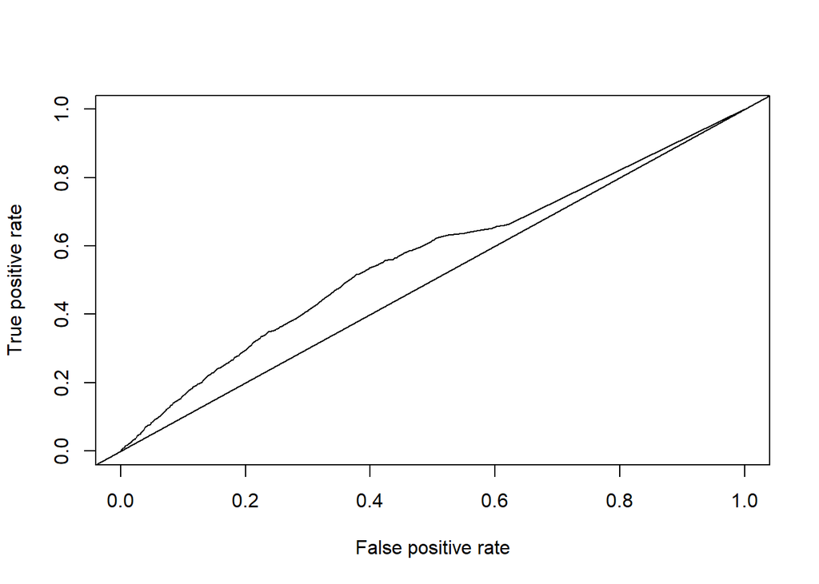

```r
# Building the roc and auc curve


score=predict(lcDT1b,lcdfTst, type="prob")[,"Charged Off"]


pred=prediction(score, lcdfTst$loan_status, label.ordering = c("Fully Paid", "Charged Off"))

    #label.ordering here specifies the 'negative', 'positive' class labels
# Closer to one specifies charged off

#ROC curve

aucPerf <-performance(pred, "tpr", "fpr")

plot(aucPerf)

abline(a=0, b= 1)
```

```r
#AUC value
aucPerf=performance(pred, "auc")

aucPerf@y.values
```

```
## [[1]]
## [1] 0.5651486
```

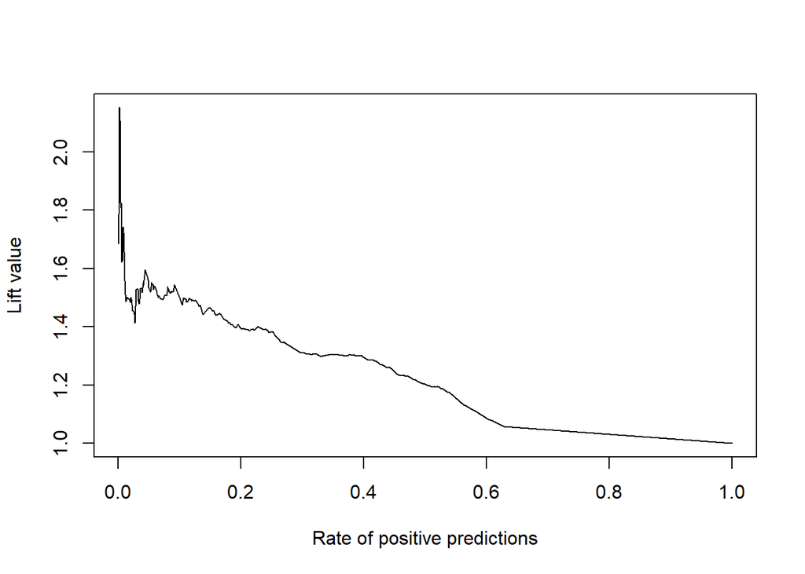

```r
#Lift curve
liftPerf <-performance(pred, "lift", "rpp")

plot(liftPerf)
```

```r
# 5. Using the model which was balanced and pruned

predProbTrn=predict(lcDT1bp,lcdfTrn, type='prob')

predTrnCT = ifelse(predProbTrn[, 'Charged Off'] > CTHRESH, 'Charged Off', 'Fully Paid')

table(predTrnCT , true=lcdfTrn$loan_status)
```

```
##              true
## predTrnCT     Charged Off Fully Paid
##   Charged Off        6740      37613
##   Fully Paid          199       5445
```

```r
predProbTst=predict(lcDT1bp,lcdfTst, type='prob')

predTstCT = ifelse(predProbTst[, 'Charged Off'] > CTHRESH, 'Charged Off', 'Fully Paid')

table(predTstCT , true=lcdfTst$loan_status)
```

```
##              true
## predTstCT     Charged Off Fully Paid
##   Charged Off        6617      37744
##   Fully Paid          228       5408
```

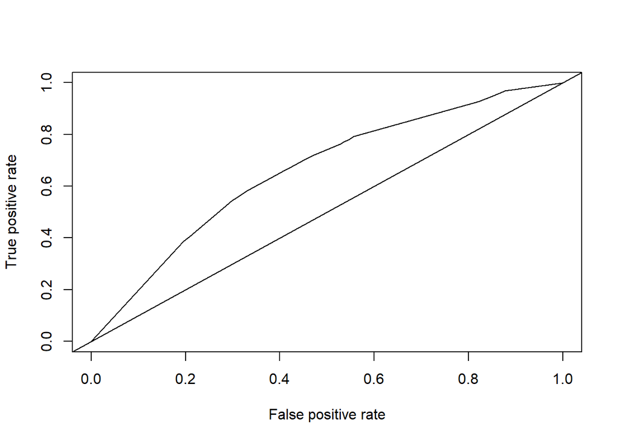

```r
# Building the roc and auc curve


score=predict(lcDT1bp,lcdfTst, type="prob")[,"Charged Off"]


pred=prediction(score, lcdfTst$loan_status, label.ordering = c("Fully Paid", "Charged Off"))

    #label.ordering here specifies the 'negative', 'positive' class labels
# Closer to one specifies charged off

#ROC curve

aucPerf <-performance(pred, "tpr", "fpr")

plot(aucPerf)

abline(a=0, b= 1)
```

```r
#AUC value
aucPerf=performance(pred, "auc")

aucPerf@y.values
```

```
## [[1]]
## [1] 0.6609658
```

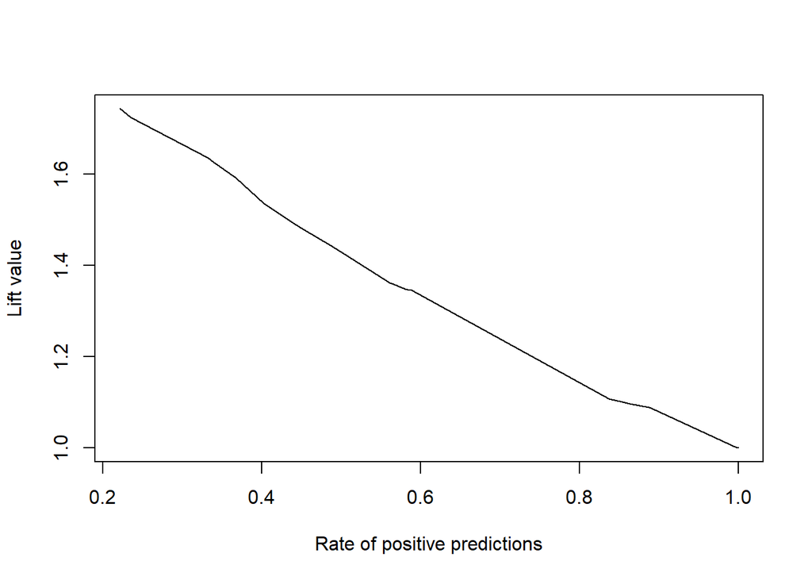

```r
#Lift curve
liftPerf <-performance(pred, "lift", "rpp")

plot(liftPerf)
```

We have observed both confusion matrix and roc auc curve for the following models - The model which was fully grown, pruned, and balanced - we added the threshold values as well.

### C50 Decision Tree Model

This algorithm uses an information entropy computation to determine the best rule that splits the data, at that node, into purer classes by minimizing the computed entropy value. This means that as each node splits the data, based on the rule at that node, each subset of data split by the rule will contain less diversity of classes and will, eventually, contain only one class [complete purity]. This process is simple to compute and therefore C50 runs quickly. C50 is robust. It can work with both numeric or categorical data [this example shows both types]. It can also tolerate missing data values. The output from the R implementation can be either a decision tree or a rule set. The output model can be used to assign [predict] a class to new unclassified data items. Reference - http://mercury.webster.edu/aleshunas/R_learning_infrastructure/Classification%20of%20data%20using%20decision%20tree%20and%20regression%20tree%20methods.html

```r
library(C50)
#Model 1

c5_DT1 <<- C5.0(loan_status ~., data=lcdfTrn %>%  select(-all_of(varsOmit)),  control=C5.0Control(minCases=30))

summary(c5_DT1)
```

```
##
## Call:
## C5.0.formula(formula = loan_status ~ ., data = lcdfTrn
##  %>% select(-all_of(varsOmit)), control = C5.0Control(minCases = 30))
##
##
## C5.0 [Release 2.07 GPL Edition]      Thu Nov 24 18:26:58 2022
## -------------------------------
##
## Class specified by attribute `outcome'
##
## Read 49997 cases (65 attributes) from undefined.data
##
## Decision tree:
##  Fully Paid (49997/6939)
##
##
## Evaluation on training data (49997 cases):
##
##      Decision Tree
##    ----------------
##    Size      Errors
##
##       1 6939(13.9%)   <<
##
##
##     (a)   (b)    <-classified as
##    ----  ----
##          6939    (a): class Charged Off
##         43058    (b): class Fully Paid
##
##
## Time: 1.6 secs
```

```r
# Model 2

# only one root node --- due to class imbalance

#Is it maybe due to the class imbalance in the data. Let us check the train data .

lcdfTrn %>% group_by(loan_status) %>% tally()
```

```
## # A tibble: 2 × 2
##   loan_status     n
##   <fct>       <int>
## 1 Charged Off  6939
## 2 Fully Paid  43058
```

```r
#To consider a more balanced data for building the tree, C%.0 has a 'weights' parameter - this can specify a vector of weights for each example

#Suppose we want to weight the 'Charged Off' examples as 6, and 'Fully Paid' examples as 1

caseWeights <<- ifelse(lcdfTrn$loan_status=="Charged Off", 6, 1)


## Error

c5_DT2 <<- C5.0(loan_status ~., data=lcdfTrn %>%  select(-all_of(varsOmit)), weights = caseWeights, control=C5.0Control(minCases=30))

summary(c5_DT2)
```

```
##
## Call:
## C5.0.formula(formula = loan_status ~ ., data = lcdfTrn
##  %>% select(-all_of(varsOmit)), weights = caseWeights, control
##  = C5.0Control(minCases = 30))
##
##
## C5.0 [Release 2.07 GPL Edition]      Thu Nov 24 18:27:05 2022
## -------------------------------
##
## Class specified by attribute `outcome'
##
## Read 49997 cases (66 attributes) from undefined.data
## Using relative case weighting
##
## Decision tree:
##
## sub_grade in {B3,B4,B5,C1,C2,C3,C4,C5,D1,D2,D3,D4,D5,E1,E2,E3,E4,E5,F1,F2,F3,
## :             F4,F5,G1,G2,G3,G4,G5}:
## :...sub_grade in {C4,C5,D1,D2,D3,D4,D5,E1,E2,E3,E4,E5,F1,F2,F3,F4,F5,G1,G3,G5}:
## :   :...int_rate > 24.5: Charged Off (204.8/27.7)
## :   :   int_rate <= 24.5:
## :   :   :...tax_liens > 2:
## :   :       :...mths_since_last_delinq <= 37: Fully Paid (37.8/7.1)
## :   :       :   mths_since_last_delinq > 37: Charged Off (33.1/11.8)
## :   :       tax_liens <= 2:
## :   :       :...loan_amnt <= 2625:
## :   :           :...num_il_tl <= 0: Charged Off (49.6/10.6)
## :   :           :   num_il_tl > 0:
## :   :           :   :...acc_open_past_24mths > 10: Charged Off (63.8/17.7)
## :   :           :       acc_open_past_24mths <= 10:
## :   :           :       :...grade in {A,B,G}: Fully Paid (0)
## :   :           :           grade in {C,F}:
## :   :           :           :...bc_open_to_buy > 2259: Fully Paid (45.5)
## :   :           :           :   bc_open_to_buy <= 2259:
## :   :           :           :   :...bc_open_to_buy <= 1508: Fully Paid (100.9/24.8)
## :   :           :           :       bc_open_to_buy > 1508: Charged Off (34.8/6.5)
## :   :           :           grade in {D,E}:
## :   :           :           :...propSatisBankcardAccts <= 0.3225806: Fully Paid (61.4/17.7)
## :   :           :               propSatisBankcardAccts > 0.3225806: [S1]
```

[output cut: 1818 more lines]

```
##    7.59% initial_list_status
##    6.34% tot_coll_amt
##    6.00% num_sats
##    5.87% revol_bal
##    5.85% delinq_2yrs
##    5.29% borrHistory
##    4.82% verification_status
##    4.39% pct_tl_nvr_dlq
##    3.14% total_bal_ex_mort
##    2.96% bc_util
##    2.63% num_actv_rev_tl
##    0.71% num_rev_tl_bal_gt_0
##
##
## Time: 2.8 secs
```

```r
predTrn <- predict(c5_DT2, lcdfTrn, type='class')

confusionMatrix(predTrn, lcdfTrn$loan_status)
```

```
## Confusion Matrix and Statistics
##
##              Reference
## Prediction    Charged Off Fully Paid
##   Charged Off        5892      14271
##   Fully Paid         1047      28787
##
##                Accuracy : 0.6936
##                  95% CI : (0.6896, 0.6977)
##     No Information Rate : 0.8612
##     P-Value [Acc > NIR] : 1
##
##                   Kappa : 0.2877
##
##  Mcnemar's Test P-Value : <0.0000000000000002
##
##             Sensitivity : 0.8491
##             Specificity : 0.6686
##          Pos Pred Value : 0.2922
##          Neg Pred Value : 0.9649
##              Prevalence : 0.1388
##          Detection Rate : 0.1178
##    Detection Prevalence : 0.4033
##       Balanced Accuracy : 0.7588
##
##        'Positive' Class : Charged Off
##
```

```r
# Test Prediction

predTst <- predict(c5_DT2, lcdfTst, type='prob')

table(pred = predTst[,'Fully Paid' ] > CTHRESH, true=lcdfTst$loan_status)
```

```
##        true
## pred    Charged Off Fully Paid
##   FALSE        2209       7964
##   TRUE         4636      35188
```

### Utilising functions

```r
#ROC curve and AUC value

fnROCPerformance <- function(scores, dat)
{  #Note the label-ordering - so, scores should be prob of 'Fully Paid'
    pred=prediction(scores, dat$loan_status, label.ordering = c("Charged Off", "Fully Paid" ))

  #ROC curve
  aucPerf <-performance(pred, "tpr", "fpr")
  plot(aucPerf)
  abline(a=0, b= 1)

  #AUC value
  aucPerf=performance(pred, "auc")
  sprintf("AUC: %f", aucPerf@y.values)

}


#decile lift performance, for minority class (Charged Off")
#   the 'score' parameter should gice 'prob' of loan_status == 'Charged Off'

fnDecileLiftsPerformance_defaults  <- function( scores, dat) {  #score is for loan_status=='Charged Off'
  totDefRate= sum(dat$loan_status=="Charged Off")/nrow(dat)
  decPerf <- data.frame(scores)
  decPerf <- cbind(decPerf, status=dat$loan_status, grade=dat$grade)
  decPerf <- decPerf %>% mutate(decile = ntile(-scores, 10))
  decPerf<-  decPerf  %>% group_by(decile) %>% summarise (
    count=n(), numDefaults=sum(status=="Charged Off"), defaultRate=numDefaults/count,
    totA=sum(grade=="A"),totB=sum(grade=="B" ), totC=sum(grade=="C"), totD=sum(grade=="D"),
    totE=sum(grade=="E"),totF=sum(grade=="F") )
  decPerf$cumDefaults=cumsum(decPerf$numDefaults)
  decPerf$cumDefaultRate=decPerf$cumDefaults/cumsum(decPerf$count)
  decPerf$cumDefaultLift<- decPerf$cumDefaultRate/(sum(decPerf$numDefaults)/sum(decPerf$count))

  print(decPerf)
}


#Returns performance by deciles
fnDecileReturnsPerformance <- function( scores, dat) {
  decRetPerf <- data.frame(scores)
  decRetPerf <- cbind(decRetPerf, status=dat$loan_status, grade=dat$grade, actRet=dat$actualReturn, actTerm = dat$actualTerm)
  decRetPerf <- decRetPerf %>% mutate(decile = ntile(-scores, 10))
  decRetPerf %>% group_by(decile) %>% summarise (
    count=n(), numDefaults=sum(status=="Charged Off"), avgActRet=mean(actRet), minRet=min(actRet), maxRet=max(actRet),
    avgTer=mean(actTerm), totA=sum(grade=="A"), totB=sum(grade=="B" ), totC=sum(grade=="C"), totD=sum(grade=="D"),
    totE=sum(grade=="E"), totF=sum(grade=="F") )
}
```

### Random Forest

```r
library(ranger)

rfModel1 <- ranger(loan_status ~., data=lcdfTrn %>%  select(-all_of(varsOmit)), num.trees = 200, importance='permutation', probability = TRUE)

#variable importance

vimp_rfGp<-importance(rfModel1)

vimp_rfGp
```

```
##                  loan_amnt                funded_amnt
##            0.0057694618931            0.0063206206214
##                   int_rate                installment
##            0.0082532838143            0.0069373777509
##                      grade                  sub_grade
##            0.0053751801769            0.0069964883426
##                 emp_length             home_ownership
##            0.0004696967194            0.0011015578657
##                 annual_inc        verification_status
##            0.0060799117598            0.0002787519789
##                    purpose                        dti
##            0.0003422433542            0.0030774148200
##                delinq_2yrs             inq_last_6mths
##            0.0003106260246            0.0010696249354
##     mths_since_last_delinq                   open_acc
##            0.0005204781463            0.0022582121068
##                    pub_rec                  revol_bal
##            0.0001307774404            0.0057976932928
##                 revol_util                  total_acc
##            0.0042871907803            0.0035813027888
##        initial_list_status collections_12_mths_ex_med
##            0.0000563870333            0.0000318724891
##             acc_now_delinq               tot_coll_amt
##            0.0000058629048            0.0002792247444
##                tot_cur_bal           total_rev_hi_lim
##            0.0127001160507            0.0098702503405
##       acc_open_past_24mths                avg_cur_bal
##            0.0040916654888            0.0094454149377
##             bc_open_to_buy                    bc_util
##            0.0084307459446            0.0055556803076
##   chargeoff_within_12_mths                delinq_amnt
##            0.0000003207080            0.0000009438058
##         mo_sin_old_il_acct       mo_sin_old_rev_tl_op
##            0.0014838509014            0.0042293265120
##      mo_sin_rcnt_rev_tl_op             mo_sin_rcnt_tl
##            0.0020828289406            0.0019723241422
##                   mort_acc       mths_since_recent_bc
##            0.0018874902899            0.0016764453058
##      mths_since_recent_inq      num_accts_ever_120_pd
##            0.0008892136005            0.0003256258383
```

[output cut: 9 more lines]

```
##            0.0024400578337            0.0000001394934
##               num_tl_30dpd         num_tl_90g_dpd_24m
##            0.0000020341977            0.0000752459910
##         num_tl_op_past_12m             pct_tl_nvr_dlq
##            0.0023768233935            0.0007716068973
##           percent_bc_gt_75       pub_rec_bankruptcies
##            0.0032333672418            0.0001546165541
##                  tax_liens            tot_hi_cred_lim
##           -0.0000135116754            0.0150207344803
##          total_bal_ex_mort             total_bc_limit
##            0.0060706556403            0.0080235952948
## total_il_high_credit_limit     propSatisBankcardAccts
##            0.0037678086186            0.0014201589287
##                borrHistory               openAccRatio
##            0.0039047195594            0.0022093232079
```

```r
#Get the predictions -- look into the returned object

scoreTrn <- predict(rfModel1,lcdfTrn) # This will have score of charged and fully paid


head(scoreTrn$predictions)
```

```
##      Charged Off Fully Paid
## [1,]  0.66966865  0.3303313
## [2,]  0.56379365  0.4362063
## [3,]  0.05327778  0.9467222
## [4,]  0.09529960  0.9047004
## [5,]  0.61560714  0.3843929
## [6,]  0.07122619  0.9287738
```

```r
#classification performance , at specific threshold

table(pred = scoreTrn$predictions[, "Fully Paid"] > 0.7, actual=lcdfTrn$loan_status)
```

```
##        actual
## pred    Charged Off Fully Paid
##   FALSE        6939          4
##   TRUE            0      43054
```

```r
scoreTst <- predict(rfModel1,lcdfTst)

# Table for the test dataset

table(pred = scoreTst$predictions[, "Fully Paid"] > 0.7, actual=lcdfTst$loan_status)
```

```
##        actual
## pred    Charged Off Fully Paid
##   FALSE        1052       2404
##   TRUE         5793      40748
```

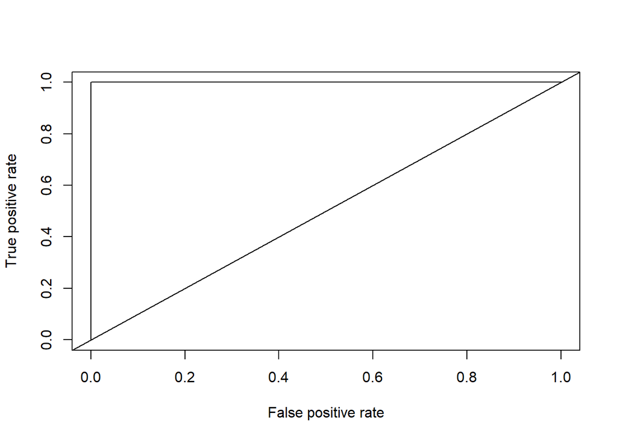

```r
#ROC curve, AUC

pred=prediction(scoreTrn$predictions[, "Fully Paid"], lcdfTrn$loan_status, label.ordering = c("Charged Off","Fully Paid" ))  #ROC curve

aucPerf <-performance(pred, "tpr", "fpr")

plot(aucPerf)

abline(a=0, b= 1)
```

```r
#AUC value

aucPerf=performance(pred, "auc")

sprintf("AUC: %f", aucPerf@y.values)
```

```
## [1] "AUC: 1.000000"
```

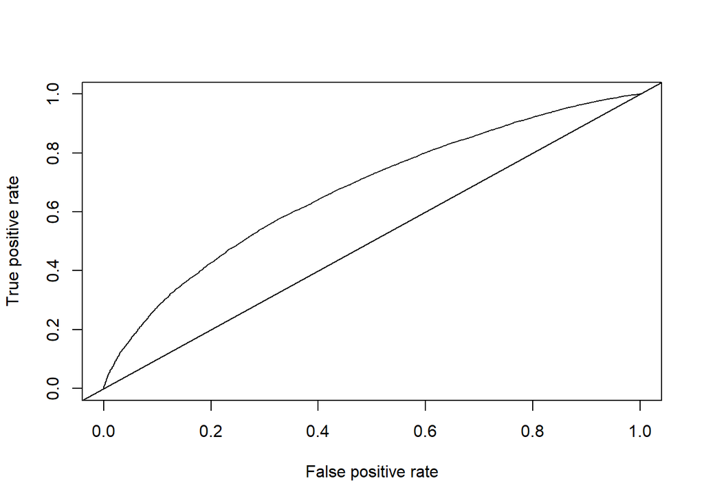

```
## [1] "AUC: 0.671017"
```

```r
# We will use the performance function created above

fnROCPerformance(predict(rfModel1,lcdfTst)$predictions[,"Fully Paid"], dat=lcdfTst)
```

```r
#for decile defaults-lift performance

fnDecileLiftsPerformance_defaults( predict(rfModel1,lcdfTrn)$predictions[,"Charged Off"], lcdfTrn  )
```

```
## # A tibble: 10 × 13
##    decile count numDefaults defaul…¹  totA  totB  totC  totD  totE  totF cumDe…²
##     <int> <int>       <int>    <dbl> <int> <int> <int> <int> <int> <int>   <int>
##  1      1  5000        5000    1        89   936  1942  1388   508   122    5000
##  2      2  5000        1939    0.388   527  1192  1344  1189   562   166    6939
##  3      3  5000           0    0        98   803  2219  1416   415    46    6939
##  4      4  5000           0    0       222  1355  2164  1043   201    15    6939
##  5      5  5000           0    0       369  1908  1949   684    86     4    6939
##  6      6  5000           0    0       616  2344  1647   352    40     1    6939
##  7      7  5000           0    0      1055  2684  1095   149    17     0    6939
##  8      8  4999           0    0      1698  2632   614    54     1     0    6939
##  9      9  4999           0    0      2567  2180   244     8     0     0    6939
## 10     10  4999           0    0      4068   908    21     2     0     0    6939
## # … with 2 more variables: cumDefaultRate <dbl>, cumDefaultLift <dbl>, and
## #   abbreviated variable names ¹defaultRate, ²cumDefaults
```

```r
     #Note- this function calculates lifts for the minority class - so score should be prob of "charged off'


# Since we are looking for returns we will use fully paid


# Creating the a new random forest model - changing few model parameters

#Different parameters for random forest - for example, if the default model is seen to overfit


# Specifing the minimum node size to 50 and max depth of 15

rfModel2 <- ranger(loan_status ~., data=lcdfTrn %>%  select(-all_of(varsOmit)),
                   num.trees =500, probability = TRUE, min.node.size = 50, max.depth = 15, importance = 'permutation')



#variable importance

vimp_rfGp<-importance(rfModel2)

vimp_rfGp
```

```
##                  loan_amnt                funded_amnt
##             0.003145831835             0.003098404631
##                   int_rate                installment
##             0.004756009629             0.003604445492
##                      grade                  sub_grade
##             0.003459693487             0.004188630090
##                 emp_length             home_ownership
##             0.000308460919             0.000515363882
##                 annual_inc        verification_status
##             0.003359792106             0.000094029691
##                    purpose                        dti
##             0.000085328869             0.001790803464
##                delinq_2yrs             inq_last_6mths
##             0.000117764283             0.000274827457
##     mths_since_last_delinq                   open_acc
##             0.000183235085             0.000901632952
##                    pub_rec                  revol_bal
##             0.000044036820             0.002491220368
##                 revol_util                  total_acc
##             0.002049169890             0.001365241344
##        initial_list_status collections_12_mths_ex_med
##            -0.000002891586             0.000015894438
##             acc_now_delinq               tot_coll_amt
##             0.000004635660             0.000054568204
##                tot_cur_bal           total_rev_hi_lim
##             0.008166439724             0.005090844150
##       acc_open_past_24mths                avg_cur_bal
##             0.002433655943             0.005723985930
##             bc_open_to_buy                    bc_util
##             0.004776786958             0.002658494574
##   chargeoff_within_12_mths                delinq_amnt
##             0.000004544947             0.000009102953
##         mo_sin_old_il_acct       mo_sin_old_rev_tl_op
##             0.000471880661             0.001761986959
##      mo_sin_rcnt_rev_tl_op             mo_sin_rcnt_tl
##             0.000837933439             0.000937970375
##                   mort_acc       mths_since_recent_bc
##             0.001017103649             0.000831929377
##      mths_since_recent_inq      num_accts_ever_120_pd
##             0.000329547356             0.000125497101
```

[output cut: 9 more lines]

```
##             0.000940826898             0.000000520791
##               num_tl_30dpd         num_tl_90g_dpd_24m
##            -0.000001571353             0.000035608477
##         num_tl_op_past_12m             pct_tl_nvr_dlq
##             0.001566360018             0.000372093918
##           percent_bc_gt_75       pub_rec_bankruptcies
##             0.001695051366             0.000058700608
##                  tax_liens            tot_hi_cred_lim
##             0.000001536989             0.009429585752
##          total_bal_ex_mort             total_bc_limit
##             0.002721133775             0.004563782122
## total_il_high_credit_limit     propSatisBankcardAccts
##             0.001672166762             0.000545688086
##                borrHistory               openAccRatio
##             0.001569365423             0.000854165188
```

```r
#Get the predictions -- look into the returned object

scoreTrn <- predict(rfModel2,lcdfTrn)

head(scoreTrn$predictions)
```

```
##      Charged Off Fully Paid
## [1,]  0.41415167  0.5858483
## [2,]  0.32382921  0.6761708
## [3,]  0.07539869  0.9246013
## [4,]  0.16329729  0.8367027
## [5,]  0.34384841  0.6561516
## [6,]  0.09160135  0.9083987
```

```r
#classification performance , at specific threshold

table(pred = scoreTrn$predictions[, "Fully Paid"] > 0.7, actual=lcdfTrn$loan_status)
```

```
##        actual
## pred    Charged Off Fully Paid
##   FALSE        3069        253
##   TRUE         3870      42805
```

```r
# Checking the same on test data

scoreTst <- predict(rfModel2,lcdfTst)

table(pred = scoreTst$predictions[, "Fully Paid"] > 0.7, actual=lcdfTst$loan_status)
```

```
##        actual
## pred    Charged Off Fully Paid
##   FALSE         624       1105
##   TRUE         6221      42047
```

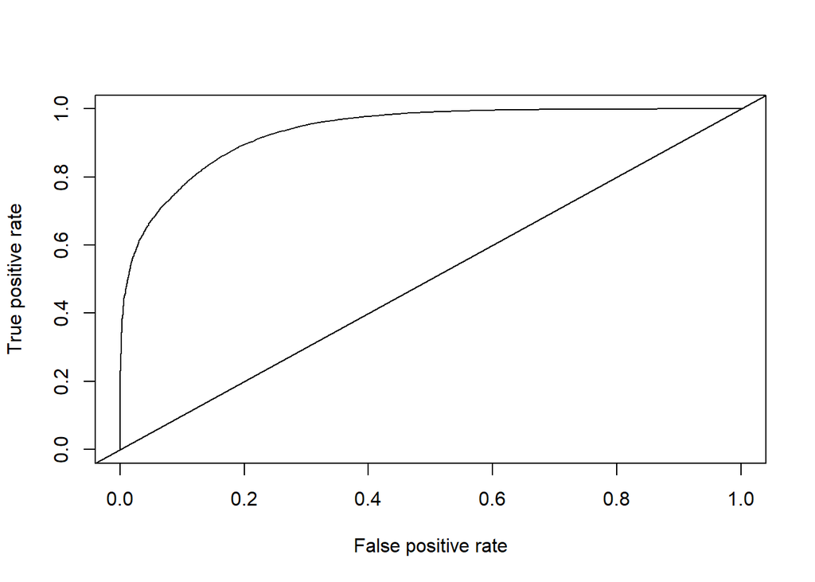

```r
#ROC curve, AUC

pred=prediction(scoreTrn$predictions[, "Fully Paid"], lcdfTrn$loan_status, label.ordering = c("Charged Off","Fully Paid" ))  #ROC curve

aucPerf <-performance(pred, "tpr", "fpr")

plot(aucPerf)

abline(a=0, b= 1)
```

```r
#AUC value

aucPerf=performance(pred, "auc")

sprintf("AUC: %f", aucPerf@y.values)
```

```
## [1] "AUC: 0.935090"
```

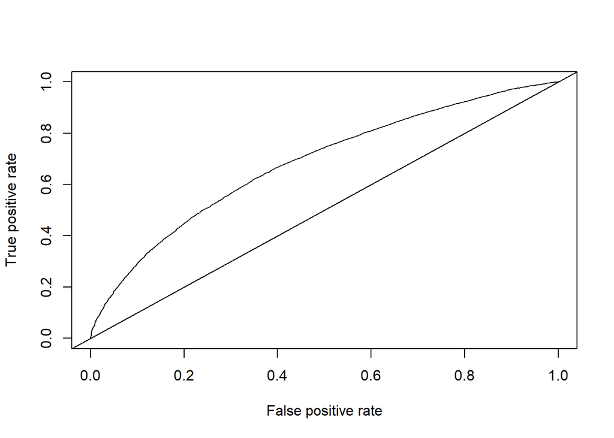

```
## [1] "AUC: 0.682814"
```

```r
#Or call the performance function defined above

fnROCPerformance(predict(rfModel2,lcdfTst)$predictions[,"Fully Paid"], dat=lcdfTst)
```

```r
     #Note- this function calculates lifts for the minority class - so score should be prob of "charged off'

#for decile returns performance

fnDecileReturnsPerformance( predict(rfModel2,lcdfTrn)$predictions[,"Fully Paid"], lcdfTrn  )
```

```
## # A tibble: 10 × 13
##    decile count numDefaults avgAc…¹ minRet maxRet avgTer  totA  totB  totC  totD
##     <int> <int>       <int>   <dbl>  <dbl>  <dbl>  <dbl> <int> <int> <int> <int>
##  1      1  5000           0    4.57    0     14.2   2.16  4792   208     0     0
##  2      2  5000           4    5.51  -23.9   15.3   2.17  3137  1838    25     0
##  3      3  5000          15    6.39  -27.6   16.9   2.16  1570  3214   213     3
##  4      4  5000          42    7.18  -31.3   25.8   2.12   748  3536   674    37
##  5      5  5000         105    7.69  -29.0   27.2   2.15   377  3004  1460   146
##  6      6  5000         231    7.95  -32.2   33.5   2.13   239  2081  2244   397
##  7      7  5000         391    8.05  -32.3   31.3   2.17   156  1252  2618   845
##  8      8  4999         609    8.04  -32.3   31.9   2.16   113   686  2503  1376
##  9      9  4999        1438    4.75  -33.3   40.2   2.37   102   620  1888  1734
## 10     10  4999        4104   -7.73  -33.3   40.8   2.85    75   503  1614  1747
## # … with 2 more variables: totE <int>, totF <int>, and abbreviated variable
## #   name ¹avgActRet
```

Our aim was to find features we should consider while making investment decision, while we started with 150+ variables, we analyzed each variable and its relation with the target variable - loan status. There are several factors to be considered - The actual return may vary from the interest shown. There are certain factors like loan grade, sub grade which are really important based on our analysis. Let us look at metric and decide as per our use case

1. Accuracy – While accuracy is important in defining how well a model is performing, we have a class imbalance problem which makes accuracy not a good measure of model performance. However, we can balance the class by oversampling and rely on this metric. Since we want to correctly predict Fully Paid loans for getting the return and correctly predict Charged off loans so as to minimize the risk of losing the money – we will check further parameters with accuracy.
2. Precision – This seems a good metric when we accurately want to predict charged off loans since we want to be very sure of our prediction.
3. Recall – What proportion of actual positives are is correctly classified - in our case with charged off loans we want to capture as many charged off loans as possible – if we want to minimize the risk.

While we would want to maxize two things at once – there is a precision recall tradeoff -

Based on our analysis, we would get an annual return of 5.5% by investing in lower risk loans – which our model predicts as Fully Paid with a accuracy of 65%. This is the return that can be expected when investing in the loan. The potential loss is -12% annually based on our calculation. The loss encompasses the return we will lose in safer investment options like CD, Savings account which provide a ~2% annual return. Hence reiterating our goal of minimizing loss while maintaining a reasonable rate of return.

For example an investment of 100 dollar should have returned 116.5 dollar at 5.5% return, but we have observed the loans are repaid by the end of 2nd year. Hence our return would be lower – We assume that the money received is added to other investment option like CD, Savings account in the last one year (which could potentially give a return of 2%), hence actual return after 3 years 113.2$.

Tuning the cost matrix will give different results and different best models. Selection can depend on use case.

Part-B

## Assignment 2 - Using GBM

```r
# gbm: Generalized Boosted Regression Modeling (GBM)

# Since the bernoulli distribution in GBM requires the distribution to be [0,1] we will convert our Charged Off and Fully paid loan status in that format.

# Let us check the values of loan status in 5 columns

lcdf$loan_status[10:15]
```

```
## [1] Fully Paid Fully Paid Fully Paid Fully Paid Fully Paid Fully Paid
## Levels: Fully Paid Charged Off
```

```r
# Let us use unclass to bring it in the required format

unclass(lcdf$loan_status)[10:15]
```

```
## [1] 1 1 1 1 1 1
```

```r
# It shows fully paid as one and charged off as 2

unclass(lcdf$loan_status)[10:15]-1
```

```
## [1] 0 0 0 0 0 0
```

```r
# Therefore the format we wanted is achieved.

## GBM Model - 1

library(gbm)

## Modeling



gbm_m1 <- gbm(formula=unclass(fct_rev(loan_status))-1 ~., data=lcdfTrn %>% select(-all_of(varsOmit)),
distribution = "bernoulli", n.trees=2000, shrinkage=0.01, interaction.depth = 4, bag.fraction=0.5, cv.folds = 5, n.cores=16)


# Distribution - Bernoulli as its a classification problem

# Number of Trees - If Lambda/Shrinkage value is small more trees will be needed

# Shrinkage Value - 0.01-0.001 Number trees for 0.001 is 10 time 0.01. However smaller shrinkage will give improved performance.

# Interaction Depth

# How to get optimal number of iterations ? 1. Independent Test Set 2. OOB Estimate 3. Cross Validation


# Lets check the results of the GBM

# Lower Lambda will make it slower.

# Depth increase might give overfit, still overfit might be less than random forest Also added time

#

gbm_m1
```

```
## gbm(formula = unclass(fct_rev(loan_status)) - 1 ~ ., distribution = "bernoulli",
##     data = lcdfTrn %>% select(-all_of(varsOmit)), n.trees = 2000,
##     interaction.depth = 4, shrinkage = 0.01, bag.fraction = 0.5,
##     cv.folds = 5, n.cores = 16)
## A gradient boosted model with bernoulli loss function.
## 2000 iterations were performed.
## The best cross-validation iteration was 1668.
## There were 64 predictors of which 60 had non-zero influence.
```

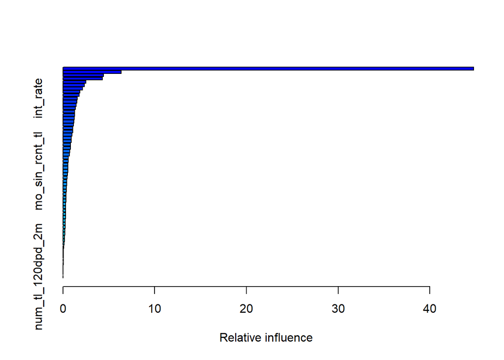

```
##                                                   var     rel.inf
## sub_grade                                   sub_grade 44.76787770
## emp_length                                 emp_length  6.34166362
## dti                                               dti  4.41831720
## acc_open_past_24mths             acc_open_past_24mths  4.31101770
## installment                               installment  2.49743241
## annual_inc                                 annual_inc  2.32159103
## mo_sin_old_rev_tl_op             mo_sin_old_rev_tl_op  2.11455218
## tot_hi_cred_lim                       tot_hi_cred_lim  1.86126757
## avg_cur_bal                               avg_cur_bal  1.76202917
## int_rate                                     int_rate  1.55669923
## mo_sin_old_il_acct                 mo_sin_old_il_acct  1.50075052
## purpose                                       purpose  1.43659177
## bc_util                                       bc_util  1.34474071
## total_rev_hi_lim                     total_rev_hi_lim  1.28659854
## bc_open_to_buy                         bc_open_to_buy  1.27041534
## mths_since_recent_bc             mths_since_recent_bc  1.23626725
## revol_util                                 revol_util  1.17922036
## borrHistory                               borrHistory  1.15863049
## loan_amnt                                   loan_amnt  1.06871852
## home_ownership                         home_ownership  1.06342935
## openAccRatio                             openAccRatio  1.00271554
## mths_since_recent_inq           mths_since_recent_inq  0.91468705
## mort_acc                                     mort_acc  0.88637111
## total_bc_limit                         total_bc_limit  0.83757598
## revol_bal                                   revol_bal  0.83592747
## total_bal_ex_mort                   total_bal_ex_mort  0.76049464
## num_actv_rev_tl                       num_actv_rev_tl  0.68505067
## grade                                           grade  0.59375583
## total_acc                                   total_acc  0.56572935
## tot_cur_bal                               tot_cur_bal  0.55531885
## tot_coll_amt                             tot_coll_amt  0.54307550
## mo_sin_rcnt_tl                         mo_sin_rcnt_tl  0.52445288
## num_tl_op_past_12m                 num_tl_op_past_12m  0.49794165
## total_il_high_credit_limit total_il_high_credit_limit  0.44231193
## num_rev_tl_bal_gt_0               num_rev_tl_bal_gt_0  0.40420939
## num_op_rev_tl                           num_op_rev_tl  0.40355530
## mths_since_last_delinq         mths_since_last_delinq  0.37933974
## inq_last_6mths                         inq_last_6mths  0.35481332
## num_il_tl                                   num_il_tl  0.33596814
```

[output cut: 10 more lines]

```
## delinq_2yrs                               delinq_2yrs  0.20041244
## percent_bc_gt_75                     percent_bc_gt_75  0.19690744
## num_sats                                     num_sats  0.17014584
## collections_12_mths_ex_med collections_12_mths_ex_med  0.15193028
## pub_rec                                       pub_rec  0.13215807
## num_accts_ever_120_pd           num_accts_ever_120_pd  0.09212256
## pub_rec_bankruptcies             pub_rec_bankruptcies  0.06126832
## initial_list_status               initial_list_status  0.04959687
## num_tl_30dpd                             num_tl_30dpd  0.03423632
## tax_liens                                   tax_liens  0.03087934
## delinq_amnt                               delinq_amnt  0.02531496
## funded_amnt                               funded_amnt  0.00000000
## acc_now_delinq                         acc_now_delinq  0.00000000
## chargeoff_within_12_mths     chargeoff_within_12_mths  0.00000000
## num_tl_120dpd_2m                     num_tl_120dpd_2m  0.00000000
```

```r
summary(gbm_m1)
```

```r
# Getting the best iteration using performance

bestIter<- gbm.perf(gbm_m1,method = 'cv')
```

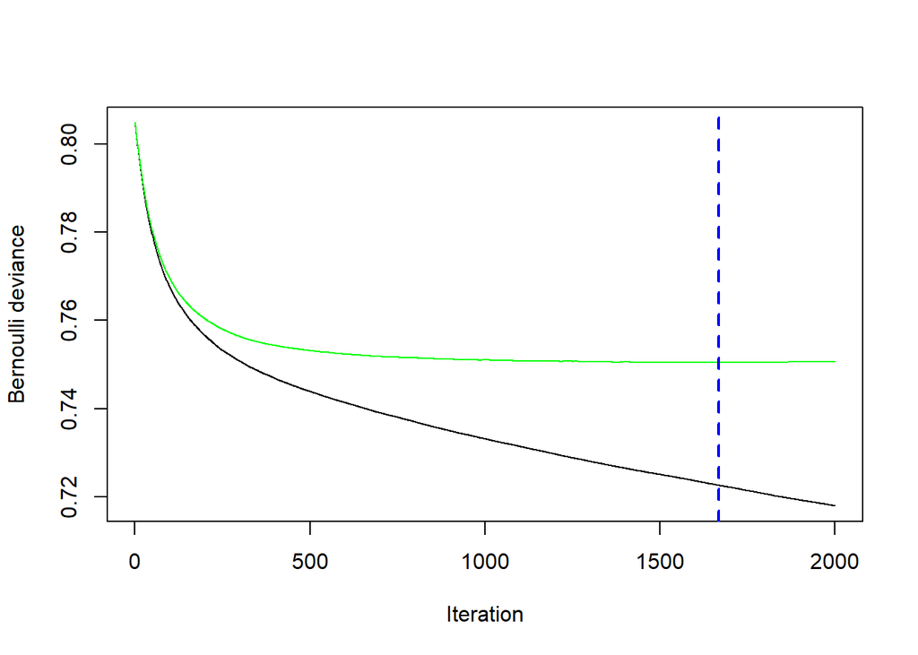

```r
bestIter
```

```
## [1] 1668
```

```r
# Predicting on the Test data with the best iteration, this will give probability of 1's - Charged off Loans

scores_gbm1<- predict(gbm_m1, newdata=lcdfTst, n.tree= bestIter, type="response")



# The probability of 1's - In our case charged off loans
head(scores_gbm1)
```

```
## [1] 0.0293822 0.1745216 0.1853985 0.1541045 0.1280684 0.1253455
```

```r
# Evaluation of the model we created - Label ordering 0,1 . In our case Fully Paid =0, Charged Off=1

pred_gbm1=prediction(scores_gbm1, lcdfTst$loan_status, label.ordering = c("Fully Paid","Charged Off"))

pred_gbm1
```

```
## A prediction instance
##   with 49997 data points
```

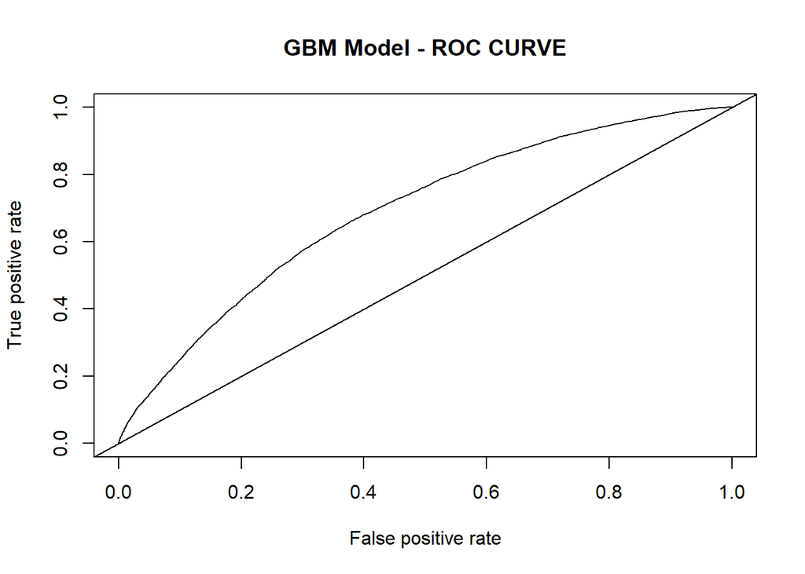

```r
# ROC/AUC


rocPerf_gbm1 <-performance(pred_gbm1, "tpr", "fpr")
plot(rocPerf_gbm1, main="GBM Model - ROC CURVE")
abline(a=0, b= 1)
```

```r
#AUC value
aucPerf_gbm1=performance(pred, "auc")

aucPerf_gbm1@y.values
```

```
## [[1]]
## [1] 0.93509
```

```r
# Automated parameter tuning - using grid search

#Parameter tuning for gbm

paramGrid <- expand.grid(
treeDepth = c(2, 5),
shrinkage = c(.001, .01, .1),
bestTree = 0,
minError = 0
)

for(i in 1 : nrow(paramGrid)) {
gbm_paramTune <- gbm(formula= unclass(loan_status)-1 ~.,
data=subset(lcdfTrn, select=-c(annRet, actualTerm, actualReturn, total_pymnt)),
distribution = "bernoulli", n.trees = 1000, interaction.depth = paramGrid$treeDepth[i], shrinkage = paramGrid$shrinkage[i],
train.fraction = 0.7,
n.cores=16 ) #use all available cores
#add best tree and its RMSE to paramGrid
paramGrid$bestTree[i] <- which.min(gbm_paramTune$valid.error)
paramGrid$minError[i] <- min(gbm_paramTune$valid.error)}

paramGrid
```

```
##   treeDepth shrinkage bestTree  minError
## 1         2     0.001     1000 0.7820725
## 2         5     0.001     1000 0.7770173
## 3         2     0.010     1000 0.7624781
## 4         5     0.010      990 0.7621001
## 5         2     0.100       97 0.7626315
## 6         5     0.100       92 0.7626917
```

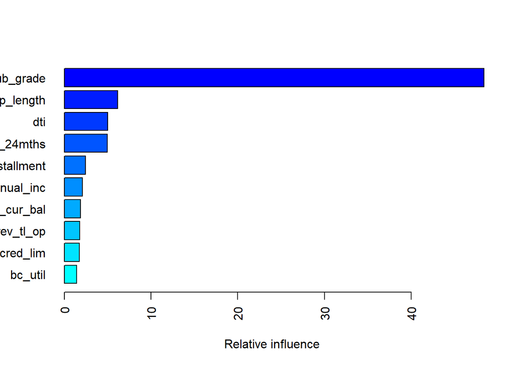

```
##                                                   var      rel.inf
## sub_grade                                   sub_grade 48.402356983
## emp_length                                 emp_length  6.164009395
## dti                                               dti  5.013119889
## acc_open_past_24mths             acc_open_past_24mths  4.955794523
## installment                               installment  2.424600042
## annual_inc                                 annual_inc  2.065106728
## avg_cur_bal                               avg_cur_bal  1.849634631
## mo_sin_old_rev_tl_op             mo_sin_old_rev_tl_op  1.786489495
## tot_hi_cred_lim                       tot_hi_cred_lim  1.719087886
## bc_util                                       bc_util  1.405745053
## home_ownership                         home_ownership  1.370342041
## mo_sin_old_il_acct                 mo_sin_old_il_acct  1.313718705
## bc_open_to_buy                         bc_open_to_buy  1.231137248
## int_rate                                     int_rate  1.212223773
## purpose                                       purpose  1.202999428
## total_rev_hi_lim                     total_rev_hi_lim  1.100688143
## mths_since_recent_bc             mths_since_recent_bc  1.079896381
## loan_amnt                                   loan_amnt  1.073145716
## mths_since_recent_inq           mths_since_recent_inq  0.997303320
## revol_util                                 revol_util  0.883586332
## mort_acc                                     mort_acc  0.824040208
## revol_bal                                   revol_bal  0.721656044
## borrHistory                               borrHistory  0.715946473
## grade                                           grade  0.664023372
## mo_sin_rcnt_tl                         mo_sin_rcnt_tl  0.644660052
## openAccRatio                             openAccRatio  0.599454111
## total_bc_limit                         total_bc_limit  0.567354002
## num_actv_rev_tl                       num_actv_rev_tl  0.522534991
## total_bal_ex_mort                   total_bal_ex_mort  0.497139304
## num_tl_op_past_12m                 num_tl_op_past_12m  0.455830883
## inq_last_6mths                         inq_last_6mths  0.440703032
## tot_cur_bal                               tot_cur_bal  0.421519346
## total_acc                                   total_acc  0.416207900
## percent_bc_gt_75                     percent_bc_gt_75  0.380524738
## total_il_high_credit_limit total_il_high_credit_limit  0.370300396
## num_rev_tl_bal_gt_0               num_rev_tl_bal_gt_0  0.365958875
## mo_sin_rcnt_rev_tl_op           mo_sin_rcnt_rev_tl_op  0.349609522
## mths_since_last_delinq         mths_since_last_delinq  0.348017596
## num_actv_bc_tl                         num_actv_bc_tl  0.343079450
```

[output cut: 10 more lines]

```
## num_bc_tl                                   num_bc_tl  0.180634084
## open_acc                                     open_acc  0.180433962
## num_il_tl                                   num_il_tl  0.154262142
## collections_12_mths_ex_med collections_12_mths_ex_med  0.105263893
## num_accts_ever_120_pd           num_accts_ever_120_pd  0.062967499
## pub_rec                                       pub_rec  0.062129787
## pub_rec_bankruptcies             pub_rec_bankruptcies  0.045543997
## num_tl_30dpd                             num_tl_30dpd  0.029804461
## delinq_amnt                               delinq_amnt  0.024789134
## initial_list_status               initial_list_status  0.022104662
## acc_now_delinq                         acc_now_delinq  0.011411203
## chargeoff_within_12_mths     chargeoff_within_12_mths  0.010591927
## tax_liens                                   tax_liens  0.009357911
## funded_amnt                               funded_amnt  0.000000000
## num_tl_120dpd_2m                     num_tl_120dpd_2m  0.000000000
```

```r
# Best Model

gbm_m2 <- gbm(formula=unclass(fct_rev(loan_status))-1 ~., data=lcdfTrn %>% select(-all_of(varsOmit)),
distribution = "bernoulli", n.trees=1000, shrinkage=0.01, interaction.depth = 5, bag.fraction=0.5, cv.folds = 5, n.cores=16)



summary(
  gbm_m2,
  cBars = 10,
  method = relative.influence, # also can use permutation.test.gbm
  las = 2
  )
```

```r
# Getting the best iteration using performance

bestIter<- gbm.perf(gbm_m2,method = 'cv')
```

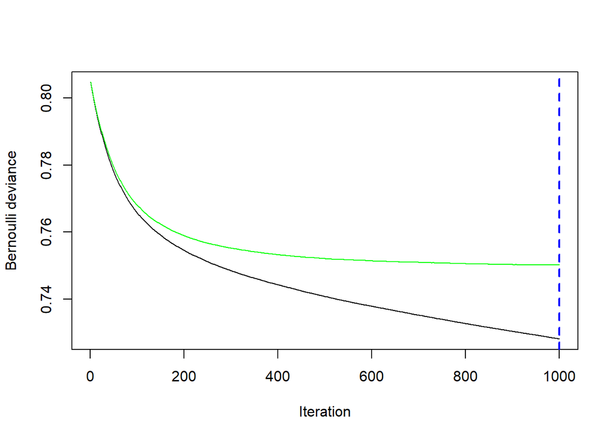

```r
bestIter
```

```
## [1] 1000
```

```r
# Predicting on the Test data with the best iteration, this will give probability of 1's - Charged off Loans

scores_gbm2<- predict(gbm_m2, newdata=lcdfTst, n.tree= bestIter, type="response")



# The probability of 1's - In our case charged off loans
head(scores_gbm2)
```

```
## [1] 0.03486272 0.19798011 0.18956697 0.15960063 0.12917869 0.12471466
```

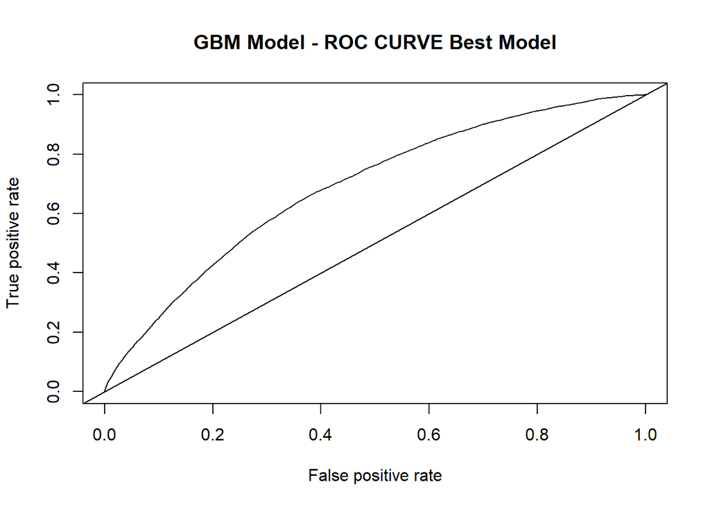

```r
# Evaluation of the model we created - Label ordering 0,1 . In our case Fully Paid =0, Charged Off=1

pred_gbm2=prediction(scores_gbm2, lcdfTst$loan_status, label.ordering = c("Fully Paid","Charged Off"))




# ROC/AUC


rocPerf_gbm2 <-performance(pred_gbm2, "tpr", "fpr")
plot(rocPerf_gbm2, main="GBM Model - ROC CURVE Best Model")
abline(a=0, b= 1)
```

```r
#AUC value
aucPerf_gbm2=performance(pred, "auc")

aucPerf_gbm2@y.values
```

```
## [[1]]
## [1] 0.93509
```

```r
### Confusion Matrix

scores_gbm2<- predict(gbm_m2, newdata=lcdfTst, n.tree= bestIter, type="response")


table(pred=as.numeric(scores_gbm2<0.15), act=lcdfTst$loan_status)
```

```
##     act
## pred Charged Off Fully Paid
##    0        4108      14003
##    1        2737      29149
```

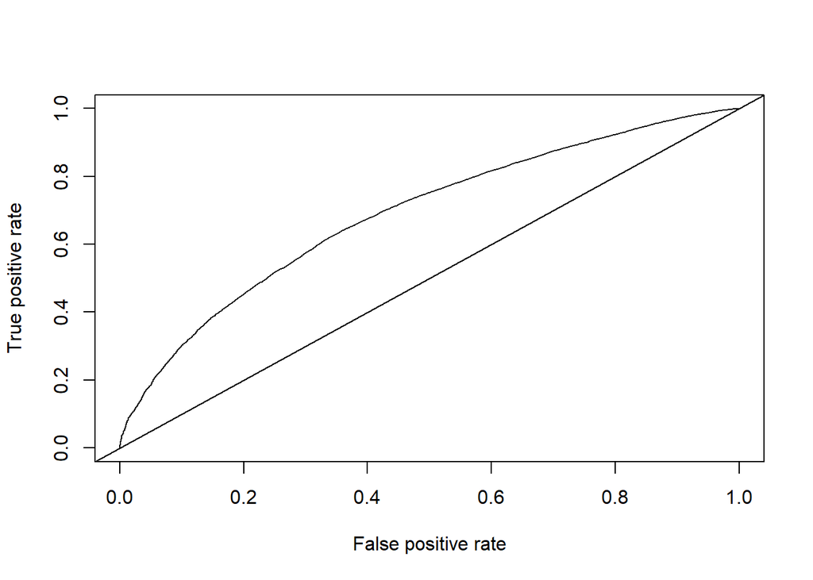

```
## [1] "AUC: 0.688586"
```

```r
### Cost Performance



fnROCPerformance(1-scores_gbm2, dat=lcdfTst)
```

```r
#Note- this function calculates lifts for the minority class - so score should be prob of "charged off'

#for decile returns performance

fnDecileReturnsPerformance( 1-scores_gbm2, lcdfTst  )
```

```
## # A tibble: 10 × 13
##    decile count numDefaults avgAc…¹ minRet maxRet avgTer  totA  totB  totC  totD
##     <int> <int>       <int>   <dbl>  <dbl>  <dbl>  <dbl> <int> <int> <int> <int>
##  1      1  5000         163    3.70  -32.3   11.1   2.22  4998     2     0     0
##  2      2  5000         272    4.43  -31.3   16.4   2.24  3899  1099     2     0
##  3      3  5000         367    4.82  -32.2   18.5   2.26  1778  3165    56     1
##  4      4  5000         470    5.32  -32.2   30.9   2.25   493  4008   481    17
##  5      5  5000         569    5.75  -32.2   23.3   2.23    86  3520  1325    63
##  6      6  5000         605    6.37  -33.3   26.8   2.22    19  2495  2198   263
##  7      7  5000         799    6.21  -31.2   34.8   2.25     4  1529  2712   679
##  8      8  4999        1013    5.73  -33.3   29.5   2.26     0   778  2841  1181
##  9      9  4999        1138    5.61  -33.3   34.2   2.27     0   327  2380  1814
## 10     10  4999        1449    4.98  -33.3   44.4   2.36     0    41  1410  2189
## # … with 2 more variables: totE <int>, totF <int>, and abbreviated variable
## #   name ¹avgActRet
```

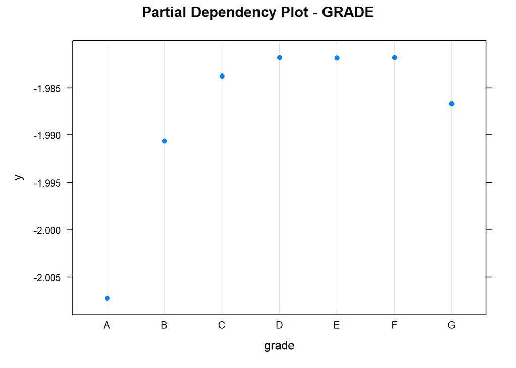

```r
# Partial Dependency plots for variables of

plot(gbm_m2, i.var='grade', main='Partial Dependency Plot - GRADE')
```

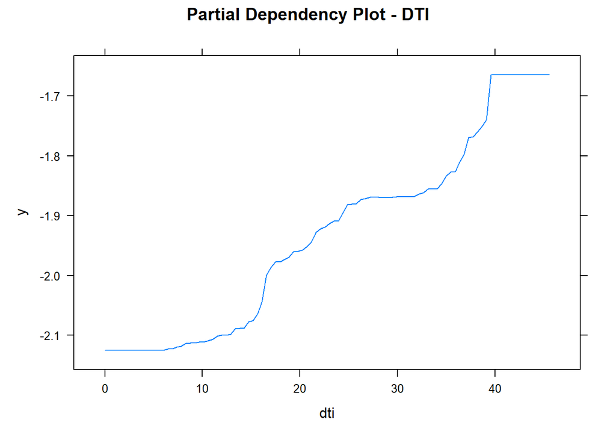

```r
plot(gbm_m2, i.var='dti', main='Partial Dependency Plot - DTI')
```

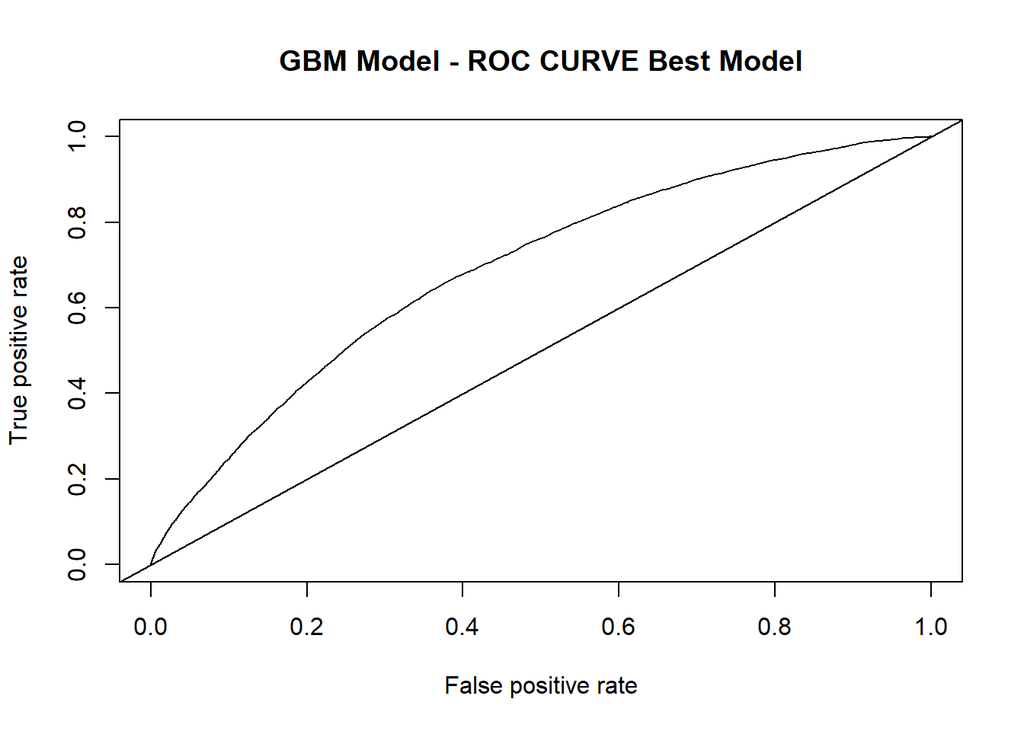

```r
## Combining the best models of Tree, Random Forest and GBM

# ROC for GBM

rocPerf_gbm2 <-performance(pred_gbm2, "tpr", "fpr")
plot(rocPerf_gbm2, main="GBM Model - ROC CURVE Best Model")
abline(a=0, b= 1)
```

### GLM - To predict Loan Status

```r
library(glmnet)
library(broom.mixed)
library(Matrix)

# Using fully paid as

levels(lcdf$loan_status)
```

```
## [1] "Fully Paid"  "Charged Off"
```

```r
yTrn<-factor(if_else(lcdfTrn$loan_status=="Fully Paid", '1', '0') )


xDTrn<-lcdfTrn %>% select(-loan_status, -actualTerm, -annRet, -actualReturn, -total_pymnt)


yTst<-factor(if_else(lcdfTst$loan_status=="Fully Paid", '1', '0') )

xDTst<-lcdfTst %>% select(-loan_status, -actualTerm, -annRet, -actualReturn, -total_pymnt)

# Running the model with alpha default - 1 Lasso

glmls_cv<- cv.glmnet(data.matrix(xDTrn), yTrn, family="binomial", alpha=1)

glmls_cv$lambda.min
```

```
## [1] 0.0002193109
```

```r
glmls_cv$lambda.1se
```

```
## [1] 0.006246054
```

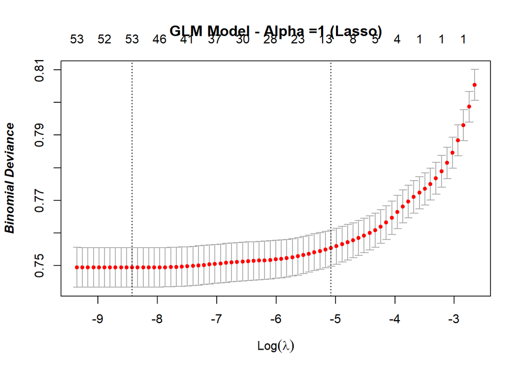

```r
#as.matrix(coef(glmls_cv, s = glmls_cv$lambda.min))
#broom.mixed:::tidy(coef(glmls_cv, s = glmls_cv$lambda.1se))
#tidy(coef(glmls_cv, s = glmls_cv$lambda.1se))

plot(glmls_cv,main="GLM Model - Alpha =1 (Lasso)",
        font.main=2, font.lab=4, font.sub=4)
```

```r
# How to select lambda - Lambda min or 1 SE

# Getting the index to 1 SE

which(glmls_cv$lambda == glmls_cv$lambda.1se)
```

```
## [1] 27
```

```r
# Ratio corresponding to 1 SE

glmls_cv$glmnet.fit$dev.ratio[which(glmls_cv$lambda == glmls_cv$lambda.1se) ]
```

```
## [1] 0.0629904
```

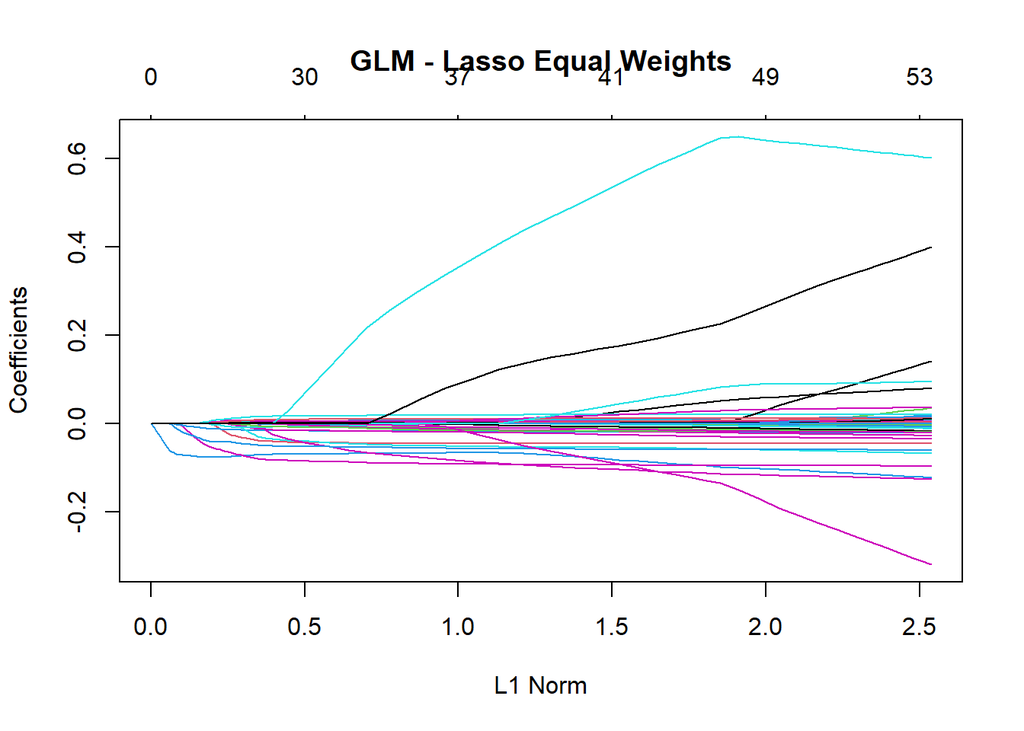

```r
plot(glmls_cv$glmnet.fit, main='GLM - Lasso Equal Weights')
```

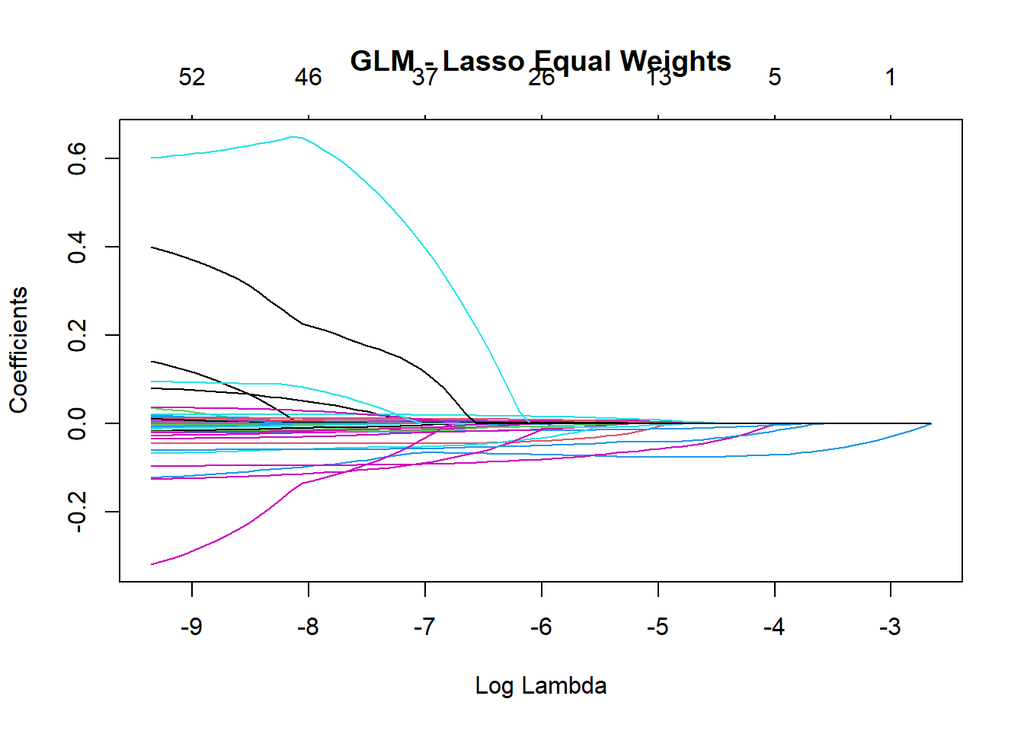

```r
plot(glmls_cv$glmnet.fit, xvar="lambda",main='GLM - Lasso Equal Weights')
```

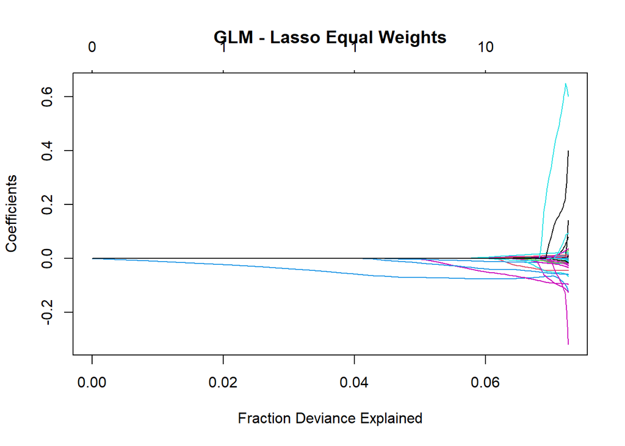

```r
plot(glmls_cv$glmnet.fit, xvar="dev",main='GLM - Lasso Equal Weights')
```

```r
# Predictions - Train data

glmPredls_1=predict ( glmls_cv,data.matrix(xDTrn), s="lambda.min") # This gives the ln(odds)

glmPredls_pc=predict(glmls_cv,data.matrix(xDTrn), s="lambda.min", type="class" ) # Gives probability of 1 - Fully Paid in our case

glmPredls_pr=predict(glmls_cv,data.matrix(xDTrn), s="lambda.min", type="response" )

# doubt about what is response - class and response

## ROC on train data


predsauc <- prediction(glmPredls_pr, lcdfTrn$loan_status, label.ordering = c("Charged Off", "Fully Paid"))

aucPerf <- performance(predsauc, "auc")

aucPerf@y.values
```

```
## [[1]]
## [1] 0.6961302
```

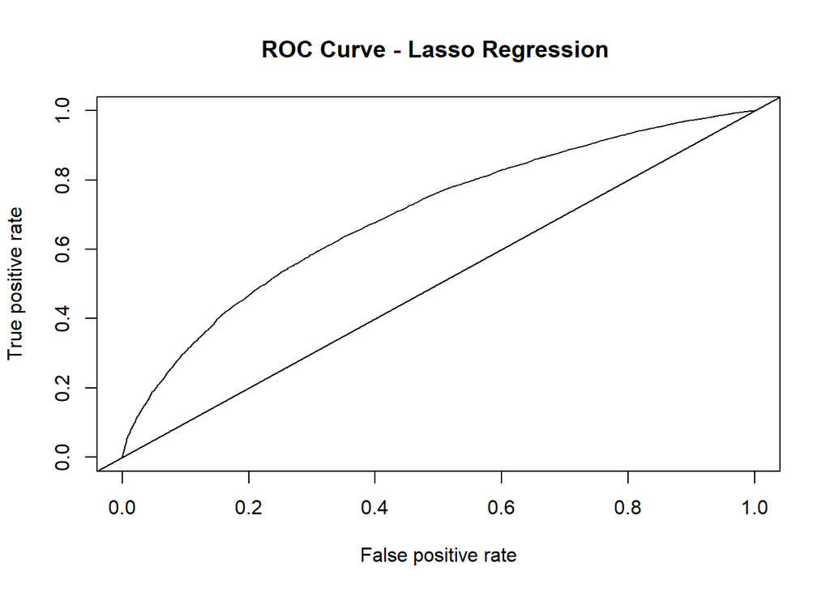

```r
aucPerf <- performance(predsauc, "tpr","fpr")

plot(aucPerf, main="ROC Curve - Lasso Regression ")

abline(a=0, b= 1)
```

```r
## Confusion matrix on train data


confusionMatrix(factor(glmPredls_pc, levels = c(1,0)), yTrn, positive = "1")
```

```
## Confusion Matrix and Statistics
##
##           Reference
## Prediction     0     1
##          0    61    63
##          1  6878 42995
##
##                Accuracy : 0.8612
##                  95% CI : (0.8581, 0.8642)
##     No Information Rate : 0.8612
##     P-Value [Acc > NIR] : 0.5135
##
##                   Kappa : 0.0125
##
##  Mcnemar's Test P-Value : <0.0000000000000002
##
##             Sensitivity : 0.998537
##             Specificity : 0.008791
##          Pos Pred Value : 0.862090
##          Neg Pred Value : 0.491935
##              Prevalence : 0.861212
##          Detection Rate : 0.859952
##    Detection Prevalence : 0.997520
##       Balanced Accuracy : 0.503664
##
##        'Positive' Class : 1
##
```

```r
## Test data

glmPredls_pc=predict(glmls_cv,data.matrix(xDTst), s="lambda.min", type="class" ) # Gives probability of 1 - Fully Paid in our case

glmPredls_pr=predict(glmls_cv,data.matrix(xDTst), s="lambda.min", type="response" )



## Test data predictions

glmPredls_pc=predict(glmls_cv,data.matrix(xDTst), s="lambda.min", type="class" ) # Gives probability of 1 - Fully Paid in our case

glmPredls_pr=predict(glmls_cv,data.matrix(xDTst), s="lambda.min", type="response" )



## ROC Curve on the test data


predsauc <- prediction(glmPredls_pr, lcdfTst$loan_status, label.ordering = c("Charged Off", "Fully Paid"))

aucPerf <- performance(predsauc, "auc")

aucPerf@y.values
```

```
## [[1]]
## [1] 0.6833865
```

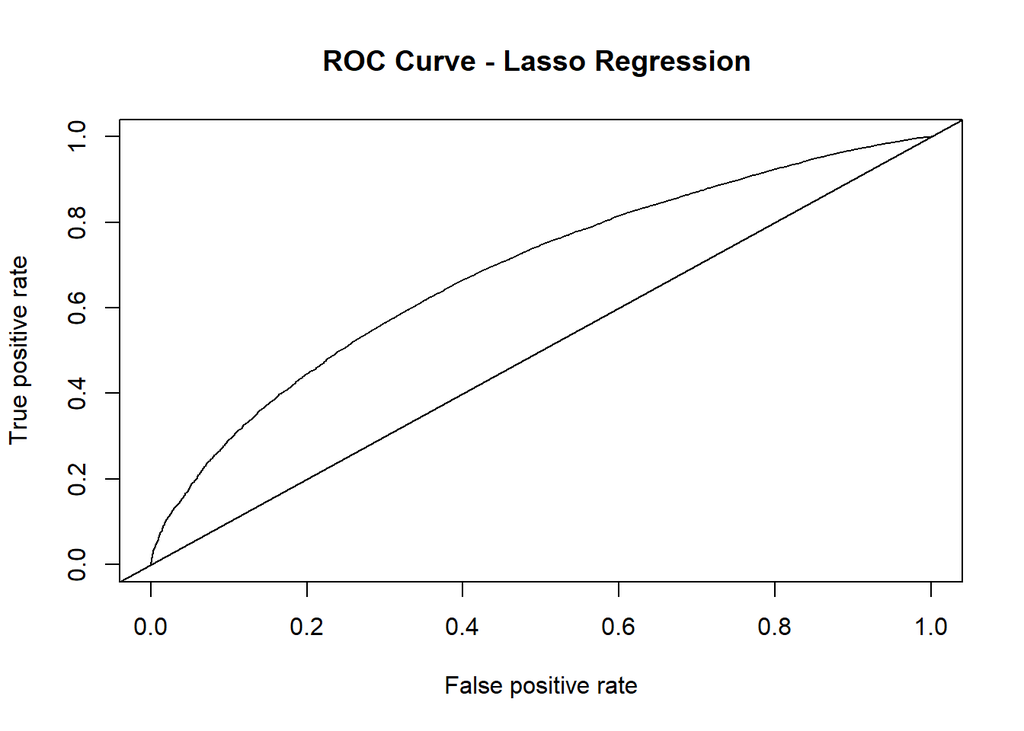

```r
aucPerf <- performance(predsauc, "tpr","fpr")

plot(aucPerf, main="ROC Curve - Lasso Regression ")

abline(a=0, b= 1)
```

```r
# Confusion Matrix


confusionMatrix(factor(glmPredls_pc, levels = c(1,0)), yTst, positive = "1")
```

```
## Confusion Matrix and Statistics
##
##           Reference
## Prediction     0     1
##          0    62    74
##          1  6783 43078
##
##                Accuracy : 0.8629
##                  95% CI : (0.8598, 0.8659)
##     No Information Rate : 0.8631
##     P-Value [Acc > NIR] : 0.5652
##
##                   Kappa : 0.0125
##
##  Mcnemar's Test P-Value : <0.0000000000000002
##
##             Sensitivity : 0.998285
##             Specificity : 0.009058
##          Pos Pred Value : 0.863962
##          Neg Pred Value : 0.455882
##              Prevalence : 0.863092
##          Detection Rate : 0.861612
##    Detection Prevalence : 0.997280
##       Balanced Accuracy : 0.503671
##
##        'Positive' Class : 1
##
```

```r
#################### Using lambda = 1.se

glmls_1se <- glmnet(data.matrix(xDTrn), yTrn, family="binomial", lambda = glmls_cv$lambda.1se)



# Comparing coeficients
tidy(glmls_1se)
```

```
## # A tibble: 14 × 5
##    term                   step     estimate  lambda dev.ratio
##    <chr>                 <dbl>        <dbl>   <dbl>     <dbl>
##  1 (Intercept)               1  3.06        0.00625    0.0630
##  2 sub_grade                 1 -0.0761      0.00625    0.0630
##  3 emp_length                1  0.00897     0.00625    0.0630
##  4 home_ownership            1 -0.0597      0.00625    0.0630
##  5 verification_status       1 -0.0119      0.00625    0.0630
##  6 dti                       1 -0.0132      0.00625    0.0630
##  7 acc_open_past_24mths      1 -0.0416      0.00625    0.0630
##  8 bc_open_to_buy            1  0.00000351  0.00625    0.0630
##  9 mo_sin_rcnt_tl            1  0.000917    0.00625    0.0630
## 10 mort_acc                  1  0.00500     0.00625    0.0630
## 11 mths_since_recent_bc      1  0.000391    0.00625    0.0630
## 12 mths_since_recent_inq     1  0.00296     0.00625    0.0630
## 13 num_actv_rev_tl           1 -0.00455     0.00625    0.0630
## 14 tot_hi_cred_lim           1  0.000000576 0.00625    0.0630
```

```r
#tidy(coef(glmls_cv, s=glmls_cv$lambda.1se))


###### Variable importance

library(vip)
tb1 <- vi_model(glmls_cv)

arrange(tb1,desc(Importance),Variable)
```

```
## # A tibble: 64 × 3
##    Variable              Importance Sign
##    <chr>                      <dbl> <chr>
##  1 sub_grade               0.0761   NEG
##  2 home_ownership          0.0597   NEG
##  3 acc_open_past_24mths    0.0416   NEG
##  4 dti                     0.0132   NEG
##  5 verification_status     0.0118   NEG
##  6 emp_length              0.00897  POS
##  7 mort_acc                0.00497  POS
##  8 num_actv_rev_tl         0.00455  NEG
##  9 mths_since_recent_inq   0.00296  POS
## 10 mo_sin_rcnt_tl          0.000918 POS
## # … with 54 more rows
```

The model is only predicting loans as fully paid hence the accuracy is higher as they are also present in large numbers. We might loose money if we predict a charged off loan as fully paid, hence we need to be careful with the accuracy metric.

### Including example weights - Balanced

```r
sum(yTrn==0) # Charged Off
```

```
## [1] 6939
```

```r
sum(yTrn==1) # Fully Paid
```

```
## [1] 43058
```

```r
1-sum(yTrn==0)/length(yTrn)
```

```
## [1] 0.8612117
```

```r
1-sum(yTrn==1)/length(yTrn)
```

```
## [1] 0.1387883
```

```r
# Assigning weights

wts = ifelse(yTrn==0, 1-sum(yTrn==0)/length(yTrn),1-sum(yTrn==1)/length(yTrn)) # Higher weights to charged off as they are less in number
wts
```

[output not shown]

[output cut: 7128 more lines]

```r
# Training a model with weights

glmls_cv_wt <- cv.glmnet(data.matrix(xDTrn), yTrn, family='binomial', weights = wts)



# Getting the index to 1 SE

which(glmls_cv_wt$lambda == glmls_cv_wt$lambda.1se)
```

```
## [1] 38
```

```r
# Ratio corresponding to 1 SE

glmls_cv_wt$glmnet.fit$dev.ratio[which(glmls_cv_wt$lambda == glmls_cv_wt$lambda.1se) ]
```

```
## [1] 0.08347046
```

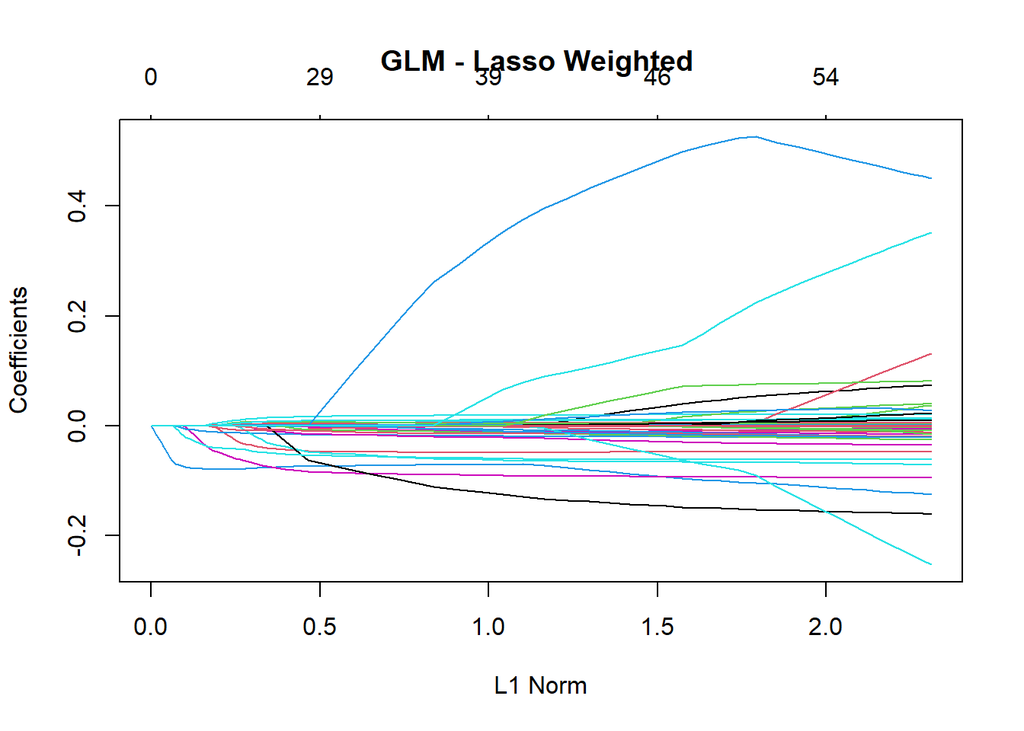

```r
plot(glmls_cv_wt$glmnet.fit, main='GLM - Lasso Weighted ')
```

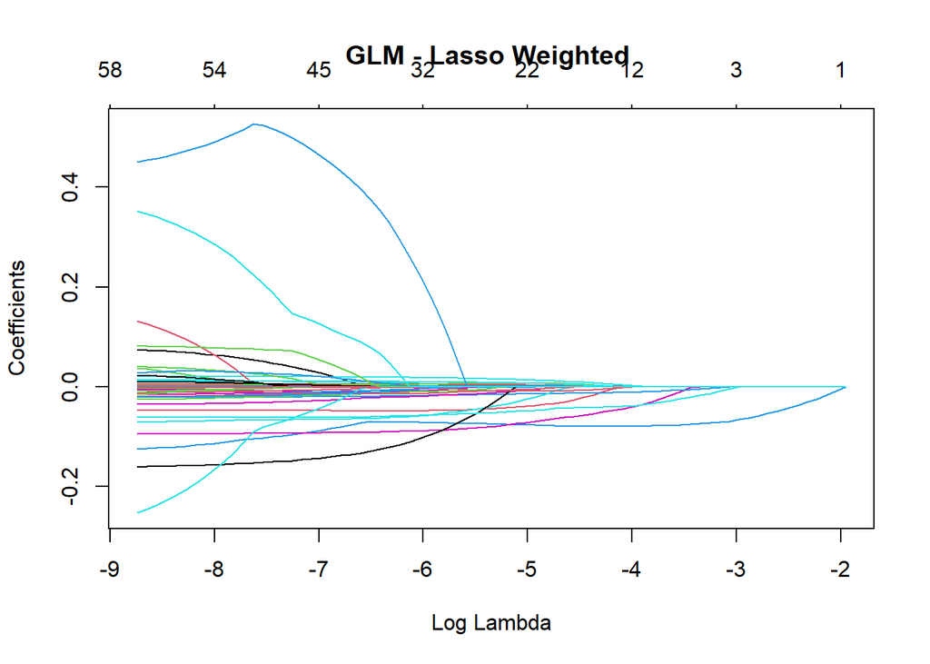

```r
plot(glmls_cv_wt$glmnet.fit, xvar="lambda",main='GLM - Lasso Weighted ')
```

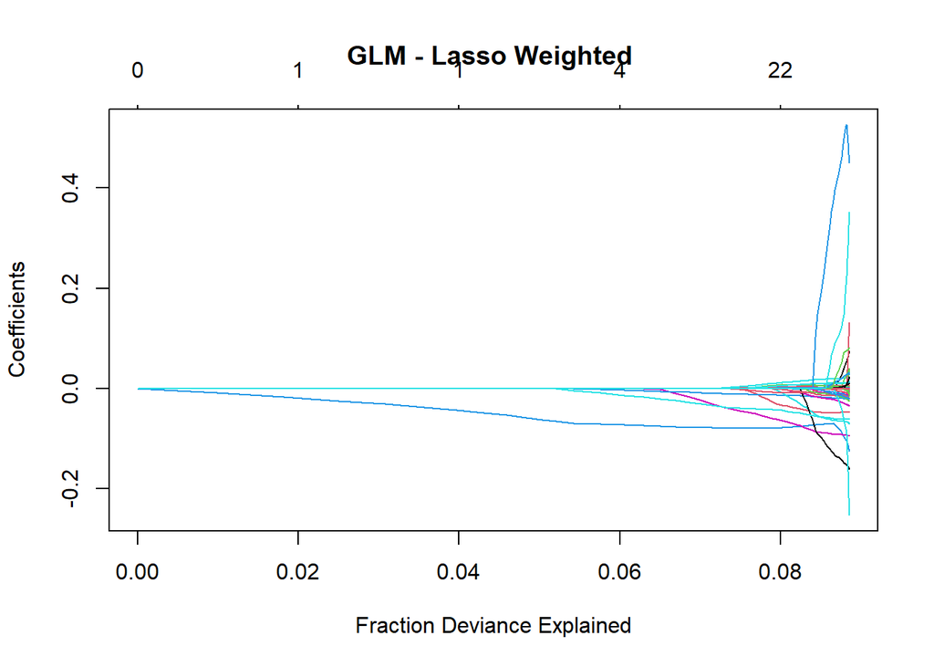

```r
plot(glmls_cv_wt$glmnet.fit, xvar="dev",main='GLM - Lasso Weighted ')
```

```r
# Predictions on the test data


glmPredls_pc=predict(glmls_cv_wt,data.matrix(xDTst), s="lambda.min", type="class" ) # Gives probability of 1 - Fully Paid in our case

glmPredls_pr=predict(glmls_cv_wt,data.matrix(xDTst), s="lambda.min", type="response" )


## ROC Curve on the test data


predsauc <- prediction(glmPredls_pr, lcdfTst$loan_status, label.ordering = c("Charged Off", "Fully Paid"))

aucPerf <- performance(predsauc, "auc")

aucPerf@y.values
```

```
## [[1]]
## [1] 0.6842042
```

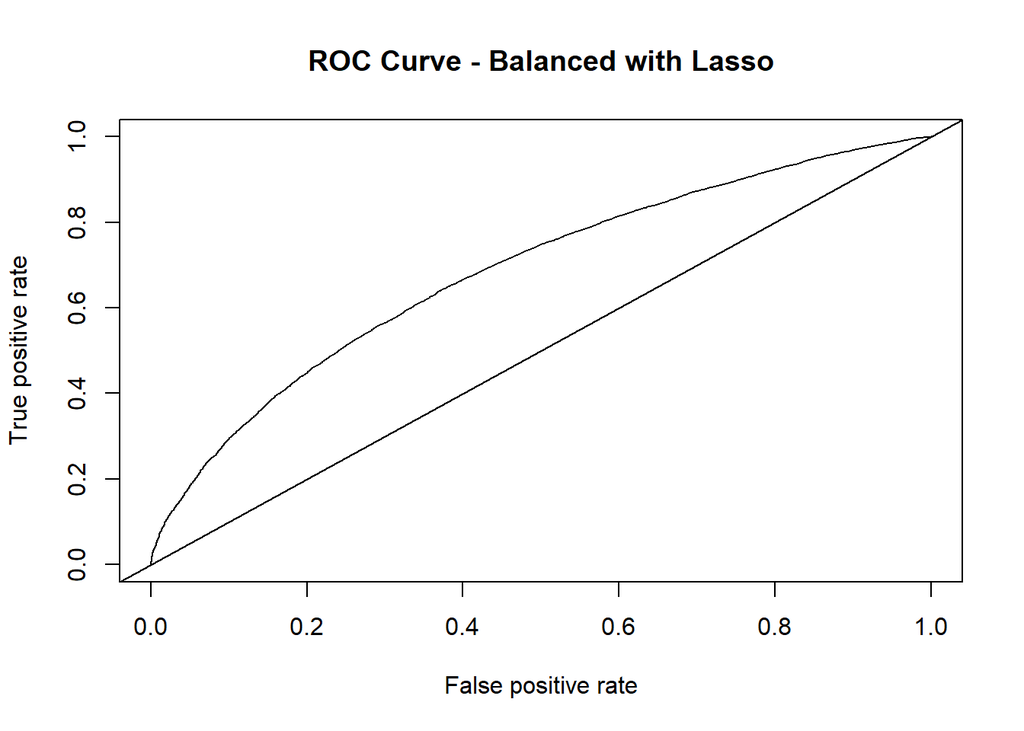

```r
aucPerf <- performance(predsauc, "tpr","fpr")

plot(aucPerf, main='ROC Curve - Balanced with Lasso')
abline(a=0, b= 1)
```

```r
# Confusion Matrix


confusionMatrix(factor(glmPredls_pc, levels = c(1,0)), yTst, positive = "1")
```

```
## Confusion Matrix and Statistics
##
##           Reference
## Prediction     0     1
##          0  4337 15758
##          1  2508 27394
##
##                Accuracy : 0.6347
##                  95% CI : (0.6304, 0.6389)
##     No Information Rate : 0.8631
##     P-Value [Acc > NIR] : 1
##
##                   Kappa : 0.1479
##
##  Mcnemar's Test P-Value : <0.0000000000000002
##
##             Sensitivity : 0.6348
##             Specificity : 0.6336
##          Pos Pred Value : 0.9161
##          Neg Pred Value : 0.2158
##              Prevalence : 0.8631
##          Detection Rate : 0.5479
##    Detection Prevalence : 0.5981
##       Balanced Accuracy : 0.6342
##
##        'Positive' Class : 1
##
```

### GLM net - AUC graph || Changing the type measure

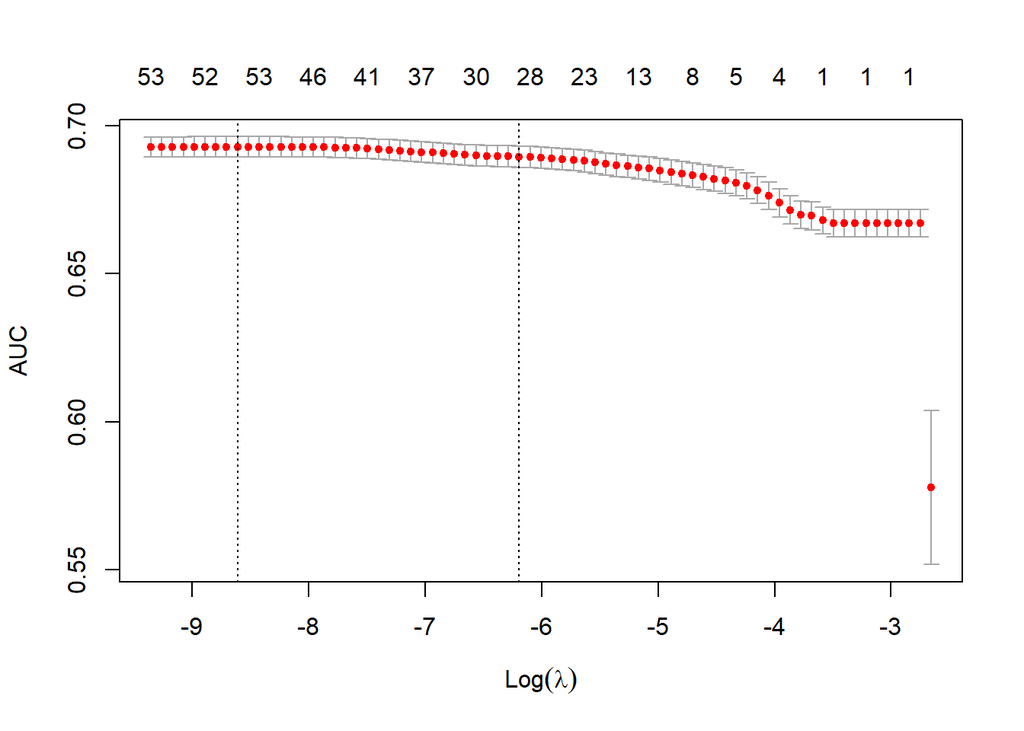

```r
# Using measure AUC since we are dealing 2 class classification

glmls_cv_auc <- cv.glmnet(data.matrix(xDTrn), yTrn, family='binomial', type.measure = "auc")

plot(glmls_cv_auc)
```

```r
# Lambda values used


glmls_cv_auc$lambda
```

```
##  [1] 0.07016342390 0.06393029870 0.05825090717 0.05307605712 0.04836092649
##  [6] 0.04406467507 0.04015009078 0.03658326738 0.03333331073 0.03037207127
## [11] 0.02767390017 0.02521542715 0.02297535810 0.02093429061 0.01907454593
## [16] 0.01738001584 0.01583602313 0.01442919449 0.01314734462 0.01197937076
## [21] 0.01091515647 0.00994548406 0.00906195466 0.00825691559 0.00752339396
## [26] 0.00685503638 0.00624605384 0.00569117163 0.00518558363 0.00472491067
## [31] 0.00430516263 0.00392270385 0.00357422165 0.00325669765 0.00296738161
## [36] 0.00270376760 0.00246357234 0.00224471536 0.00204530104 0.00186360213
## [41] 0.00169804485 0.00154719523 0.00140974667 0.00128450866 0.00117039645
## [46] 0.00106642166 0.00097168370 0.00088536199 0.00080670887 0.00073504308
## [51] 0.00066974388 0.00061024568 0.00055603314 0.00050663668 0.00046162848
## [56] 0.00042061868 0.00038325207 0.00034920501 0.00031818260 0.00028991614
## [61] 0.00026416079 0.00024069347 0.00021931093 0.00019982795 0.00018207578
## [66] 0.00016590067 0.00015116251 0.00013773365 0.00012549778 0.00011434890
## [71] 0.00010419046 0.00009493446 0.00008650075
```

```r
# Cross validation loss at each lambda

glmls_cv_auc$cvm
```

```
##  [1] 0.5778495 0.6670417 0.6670417 0.6670417 0.6670417 0.6670417 0.6670417
##  [8] 0.6670417 0.6670417 0.6670417 0.6679719 0.6695498 0.6699419 0.6715135
## [15] 0.6738865 0.6762707 0.6781810 0.6796240 0.6806766 0.6814667 0.6820747
## [22] 0.6826824 0.6832651 0.6837674 0.6843014 0.6849219 0.6854658 0.6858966
## [29] 0.6862417 0.6865883 0.6870423 0.6875675 0.6880320 0.6884159 0.6887291
## [36] 0.6889864 0.6891750 0.6893485 0.6895034 0.6896342 0.6897226 0.6898134
## [43] 0.6899798 0.6901486 0.6903913 0.6906666 0.6909040 0.6911035 0.6913051
## [50] 0.6915618 0.6918320 0.6920646 0.6922485 0.6924063 0.6925467 0.6926377
## [57] 0.6927198 0.6927733 0.6928173 0.6928468 0.6928548 0.6928663 0.6928603
## [64] 0.6928611 0.6928684 0.6928654 0.6928650 0.6928625 0.6928515 0.6928360
## [71] 0.6928282 0.6928195 0.6928008
```

```r
# Calculating the loss value at lambda = 1se

glmls_cv_auc$cvm [ which(glmls_cv_auc$lambda == glmls_cv_auc$lambda.1se) ]
```

```
## [1] 0.6895034
```

### GLMNET - Different values if alpha (alpha = 0,Ridge regression)

```r
## Ridge regression on classification - 1 - Fully paid and 0 - charged off - Using the unbalanced dataset

# Building the model using training data

glmls_cv_ridge <- cv.glmnet(data.matrix(xDTrn), yTrn, family="binomial", alpha=0)


glmls_cv_ridge$lambda.min
```

```
## [1] 0.007016342
```

```r
glmls_cv_ridge$lambda.1se
```

```
## [1] 0.1254978
```

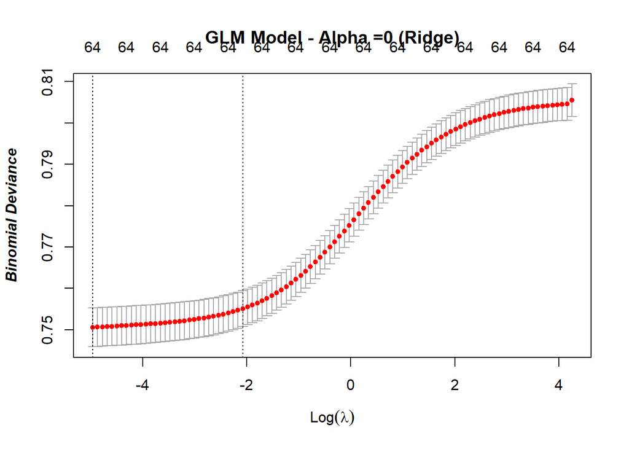

```r
#as.matrix(coef(glmls_cv_ridge, s = glmls_cv_ridge$lambda.min))

#tidy(coef(glmls_cv_ridge, s = glmls_cv_ridge$lambda.1se))

plot(glmls_cv_ridge,main="GLM Model - Alpha =0 (Ridge)",
        font.main=2, font.lab=4, font.sub=4)
```

```r
# Evaluating the performance of the model using test data



glmPredls_pc=predict(glmls_cv_ridge,data.matrix(xDTst), s="lambda.min", type="class" ) # Gives probability of 1 - Fully Paid in our case

glmPredls_pr=predict(glmls_cv_ridge,data.matrix(xDTst), s="lambda.min", type="response" )


## ROC Curve on the test data


predsauc <- prediction(glmPredls_pr, lcdfTst$loan_status, label.ordering = c("Charged Off", "Fully Paid"))

aucPerf <- performance(predsauc, "auc")

aucPerf@y.values
```

```
## [[1]]
## [1] 0.682533
```

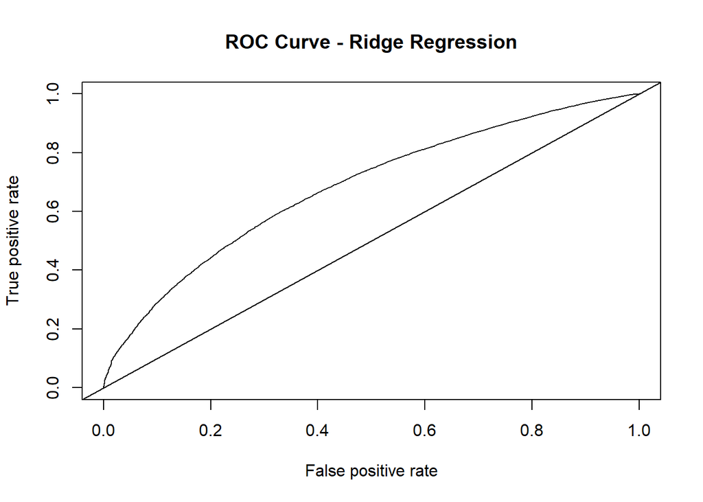

```r
aucPerf <- performance(predsauc, "tpr","fpr")

plot(aucPerf,main="ROC Curve - Ridge Regression")
abline(a=0, b= 1)
```

```r
# Confusion Matrix


confusionMatrix(factor(glmPredls_pc, levels = c(1,0)), yTst, positive = "1")
```

```
## Confusion Matrix and Statistics
##
##           Reference
## Prediction     0     1
##          0    51    56
##          1  6794 43096
##
##                Accuracy : 0.863
##                  95% CI : (0.8599, 0.866)
##     No Information Rate : 0.8631
##     P-Value [Acc > NIR] : 0.5291
##
##                   Kappa : 0.0105
##
##  Mcnemar's Test P-Value : <0.0000000000000002
##
##             Sensitivity : 0.998702
##             Specificity : 0.007451
##          Pos Pred Value : 0.863820
##          Neg Pred Value : 0.476636
##              Prevalence : 0.863092
##          Detection Rate : 0.861972
##    Detection Prevalence : 0.997860
##       Balanced Accuracy : 0.503076
##
##        'Positive' Class : 1
##
```

## Balanced dataset and ridge regression

```r
# Training a model with weights and ridge regression

# We are using the same weight parameter we created earlier



glmls_cv_ridge_wt <- cv.glmnet(data.matrix(xDTrn), yTrn, family='binomial', weights = wts, alpha=0)


glmls_cv_ridge_wt$lambda.min
```

```
## [1] 0.01421124
```

```r
glmls_cv_ridge_wt$lambda.1se
```

```
## [1] 0.09135092
```

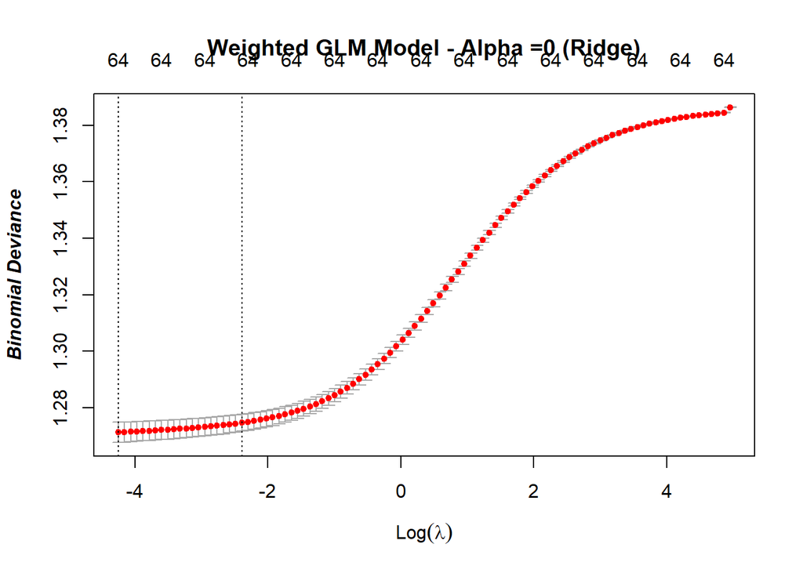

```r
#as.matrix(coef(glmls_cv_ridge_wt, s = glmls_cv_ridge_wt$lambda.min))

#tidy(coef(glmls_cv_ridge_wt, s = glmls_cv_ridge_wt$lambda.1se))

plot(glmls_cv_ridge_wt,main="Weighted GLM Model - Alpha =0 (Ridge)",
        font.main=2, font.lab=4, font.sub=4)
```

```r
# Checking the model performance on test data



glmPredls_pc=predict(glmls_cv_ridge_wt,data.matrix(xDTst), s="lambda.min", type="class" ) # Gives probability of 1 - Fully Paid in our case

glmPredls_pr=predict(glmls_cv_ridge_wt,data.matrix(xDTst), s="lambda.min", type="response" )


## ROC Curve on the test data


predsauc <- prediction(glmPredls_pr, lcdfTst$loan_status, label.ordering = c("Charged Off", "Fully Paid"))

aucPerf <- performance(predsauc, "auc")

aucPerf@y.values
```

```
## [[1]]
## [1] 0.6831095
```

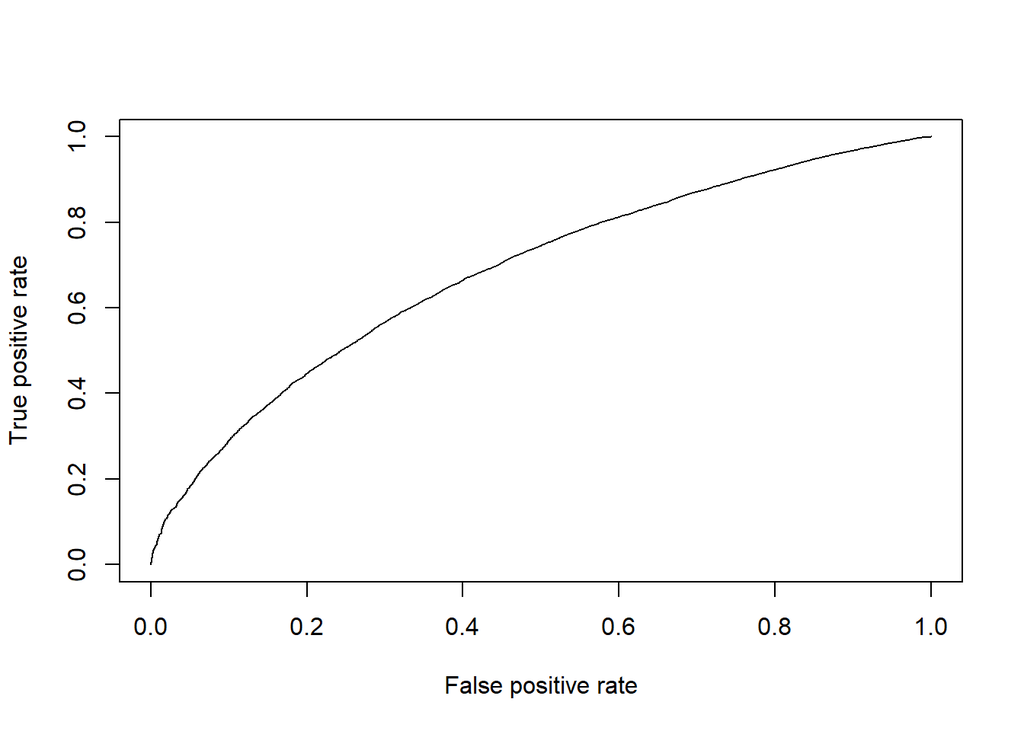

```r
aucPerf <- performance(predsauc, "tpr","fpr")

plot(aucPerf)
```

```r
# Confusion Matrix


confusionMatrix(factor(glmPredls_pc, levels = c(1,0)), yTst, positive = "1")
```

```
## Confusion Matrix and Statistics
##
##           Reference
## Prediction     0     1
##          0  4348 15920
##          1  2497 27232
##
##                Accuracy : 0.6316
##                  95% CI : (0.6274, 0.6359)
##     No Information Rate : 0.8631
##     P-Value [Acc > NIR] : 1
##
##                   Kappa : 0.1459
##
##  Mcnemar's Test P-Value : <0.0000000000000002
##
##             Sensitivity : 0.6311
##             Specificity : 0.6352
##          Pos Pred Value : 0.9160
##          Neg Pred Value : 0.2145
##              Prevalence : 0.8631
##          Detection Rate : 0.5447
##    Detection Prevalence : 0.5946
##       Balanced Accuracy : 0.6331
##
##        'Positive' Class : 1
##
```

### Changing the size of train and test data (incresing the size of train data) - 70 Percent

```r
## set the seed to make your partition reproducible
set.seed(123)

TRNPROP = 0.7  #proportion of examples in the training sample



nr<-nrow(lcdf)

round(TRNPROP * nr)
```

```
## [1] 69996
```

```r
trnIndex<- sample(1:nr, size = round(TRNPROP * nr), replace=FALSE)

lcdfTrn7 <- lcdf[trnIndex, ] # Train data

lcdfTst7 <- lcdf[-trnIndex, ] # Test data




# Using fully paid as

levels(lcdf$loan_status)
```

```
## [1] "Fully Paid"  "Charged Off"
```

```r
yTrn7<-factor(if_else(lcdfTrn7$loan_status=="Fully Paid", '1', '0') )


xDTrn7<-lcdfTrn7 %>% select(-loan_status, -actualTerm, -annRet, -actualReturn, -total_pymnt)


yTst7<-factor(if_else(lcdfTst7$loan_status=="Fully Paid", '1', '0') )

xDTst7<-lcdfTst7 %>% select(-loan_status, -actualTerm, -annRet, -actualReturn, -total_pymnt)

# Running the model with alpha default - 1 Lasso

glmls_cv_7<- cv.glmnet(data.matrix(xDTrn7), yTrn7, family="binomial", alpha=1)

glmls_cv_7$lambda.min
```

```
## [1] 0.0001520639
```

```r
glmls_cv_7$lambda.1se
```

```
## [1] 0.005216505
```

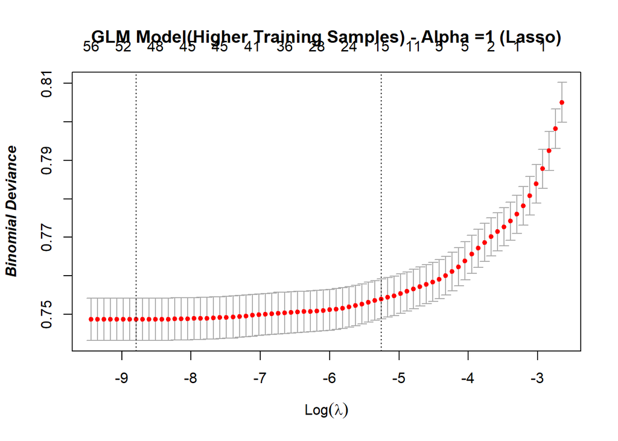

```r
#as.matrix(coef(glmls_cv_7, s = glmls_cv_7$lambda.min))

#tidy(coef(glmls_cv_7, s = glmls_cv_7$lambda.1se))

plot(glmls_cv_7,main="GLM Model(Higher Training Samples) - Alpha =1 (Lasso)",
        font.main=2, font.lab=4, font.sub=4)
```

```r
# How to select lambda - Lambda min or 1 SE

# Getting the index to 1 SE

which(glmls_cv_7$lambda == glmls_cv$lambda.1se)
```

```
## integer(0)
```

```r
# Ratio corresponding to 1 SE

glmls_cv_7$glmnet.fit$dev.ratio[which(glmls_cv_7$lambda == glmls_cv_7$lambda.1se) ]
```

```
## [1] 0.0640246
```

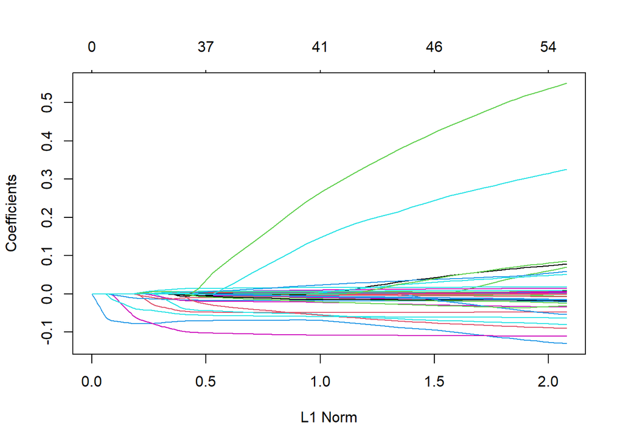

```r
plot(glmls_cv_7$glmnet.fit)
```

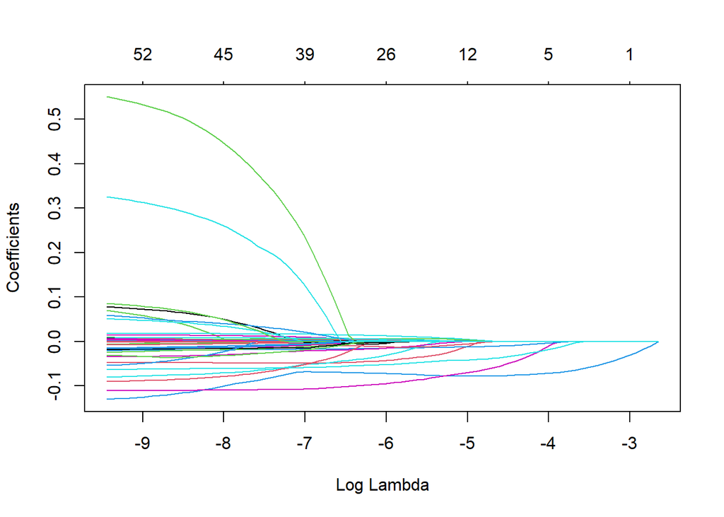

```r
plot(glmls_cv_7$glmnet.fit, xvar="lambda")
```

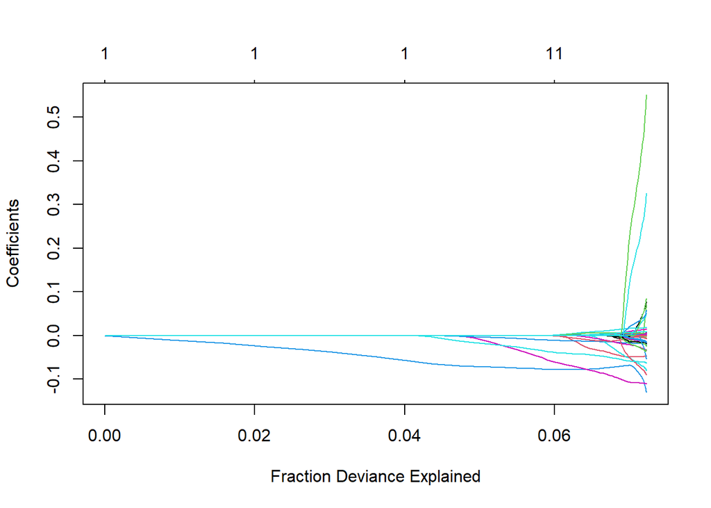

```r
plot(glmls_cv_7$glmnet.fit, xvar="dev")
```

```r
# Predictions - Train data

glmPredls_1=predict ( glmls_cv_7,data.matrix(xDTrn7), s="lambda.min") # This gives the ln(odds)

glmPredls_pc=predict(glmls_cv_7,data.matrix(xDTrn7), s="lambda.min", type="class" ) # Gives probability of 1 - Fully Paid in our case

glmPredls_pr=predict(glmls_cv_7,data.matrix(xDTrn7), s="lambda.min", type="response" )

# doubt about what is response - class and response

## ROC on train data


predsauc <- prediction(glmPredls_pr, lcdfTrn7$loan_status, label.ordering = c("Charged Off", "Fully Paid"))

aucPerf <- performance(predsauc, "auc")

aucPerf@y.values
```

```
## [[1]]
## [1] 0.6955292
```

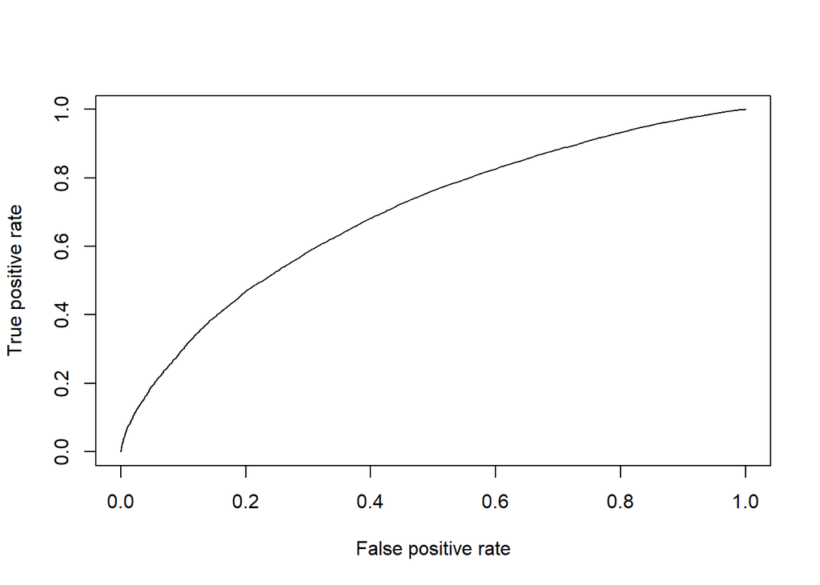

```r
aucPerf <- performance(predsauc, "tpr","fpr")

plot(aucPerf)
```

```r
## Confusion matrix on train data


confusionMatrix(factor(glmPredls_pc, levels = c(1,0)), yTrn7, positive = "1")
```

```
## Confusion Matrix and Statistics
##
##           Reference
## Prediction     0     1
##          0    96    89
##          1  9611 60200
##
##                Accuracy : 0.8614
##                  95% CI : (0.8588, 0.864)
##     No Information Rate : 0.8613
##     P-Value [Acc > NIR] : 0.4722
##
##                   Kappa : 0.0143
##
##  Mcnemar's Test P-Value : <0.0000000000000002
##
##             Sensitivity : 0.99852
##             Specificity : 0.00989
##          Pos Pred Value : 0.86233
##          Neg Pred Value : 0.51892
##              Prevalence : 0.86132
##          Detection Rate : 0.86005
##    Detection Prevalence : 0.99736
##       Balanced Accuracy : 0.50421
##
##        'Positive' Class : 1
##
```

```r
## Test data

glmPredls_pc=predict(glmls_cv_7,data.matrix(xDTst7), s="lambda.min", type="class" ) # Gives probability of 1 - Fully Paid in our case

glmPredls_pr=predict(glmls_cv_7,data.matrix(xDTst7), s="lambda.min", type="response" )



## Test data predictions

glmPredls_pc=predict(glmls_cv_7,data.matrix(xDTst7), s="lambda.min", type="class" ) # Gives probability of 1 - Fully Paid in our case

glmPredls_pr=predict(glmls_cv_7,data.matrix(xDTst7), s="lambda.min", type="response" )



## ROC Curve on the test data


predsauc <- prediction(glmPredls_pr, lcdfTst7$loan_status, label.ordering = c("Charged Off", "Fully Paid"))

aucPerf <- performance(predsauc, "auc")

aucPerf@y.values
```

```
## [[1]]
## [1] 0.6781985
```

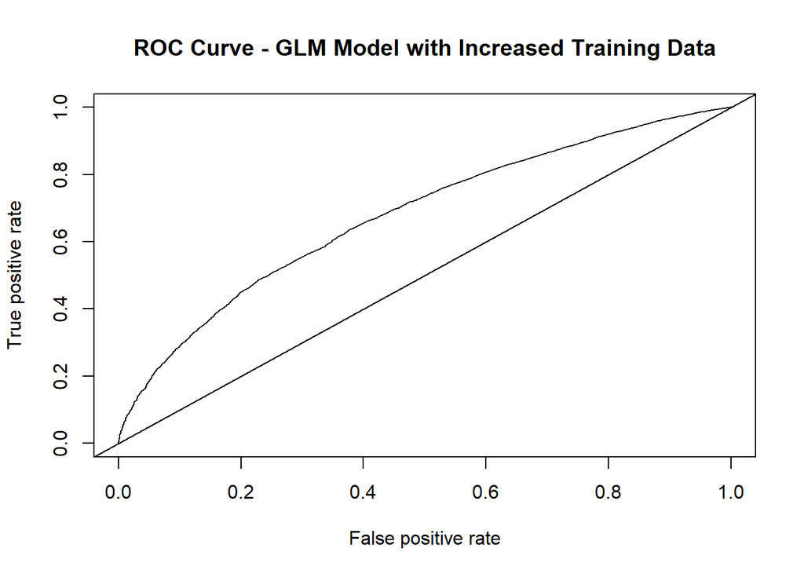

```r
aucPerf <- performance(predsauc, "tpr","fpr")

plot(aucPerf,main="ROC Curve - GLM Model with Increased Training Data")
abline(a=0, b= 1)
```

```r
# Confusion Matrix


confusionMatrix(factor(glmPredls_pc, levels = c(1,0)), yTst7, positive = "1")
```

```
## Confusion Matrix and Statistics
##
##           Reference
## Prediction     0     1
##          0    35    52
##          1  4042 25869
##
##                Accuracy : 0.8635
##                  95% CI : (0.8596, 0.8674)
##     No Information Rate : 0.8641
##     P-Value [Acc > NIR] : 0.6167
##
##                   Kappa : 0.0112
##
##  Mcnemar's Test P-Value : <0.0000000000000002
##
##             Sensitivity : 0.997994
##             Specificity : 0.008585
##          Pos Pred Value : 0.864866
##          Neg Pred Value : 0.402299
##              Prevalence : 0.864091
##          Detection Rate : 0.862357
##    Detection Prevalence : 0.997100
##       Balanced Accuracy : 0.503289
##
##        'Positive' Class : 1
##
```

```r
#################### Using lambda = 1.se

glmls_1se <- glmnet(data.matrix(xDTrn7), yTrn7, family="binomial", lambda = glmls_cv$lambda.1se)



# Comparing coeficients
tidy(glmls_1se)
```

```
## # A tibble: 13 × 5
##    term                  step     estimate  lambda dev.ratio
##    <chr>                <dbl>        <dbl>   <dbl>     <dbl>
##  1 (Intercept)              1  3.17        0.00625    0.0630
##  2 sub_grade                1 -0.0779      0.00625    0.0630
##  3 emp_length               1  0.00582     0.00625    0.0630
##  4 home_ownership           1 -0.0722      0.00625    0.0630
##  5 annual_inc               1  0.000000272 0.00625    0.0630
##  6 verification_status      1 -0.0158      0.00625    0.0630
##  7 dti                      1 -0.0126      0.00625    0.0630
##  8 acc_open_past_24mths     1 -0.0424      0.00625    0.0630
##  9 bc_open_to_buy           1  0.00000247  0.00625    0.0630
## 10 mort_acc                 1  0.00387     0.00625    0.0630
## 11 mths_since_recent_bc     1  0.000615    0.00625    0.0630
## 12 num_actv_rev_tl          1 -0.00630     0.00625    0.0630
## 13 tot_hi_cred_lim          1  0.000000461 0.00625    0.0630
```

```r
#tidy(coef(glmls_cv, s=glmls_cv$lambda.1se))


###### Variable importance

library(vip)
tb1 <- vi_model(glmls_cv)

arrange(tb1,desc(Importance),Variable)
```

```
## # A tibble: 64 × 3
##    Variable              Importance Sign
##    <chr>                      <dbl> <chr>
##  1 sub_grade               0.0761   NEG
##  2 home_ownership          0.0597   NEG
##  3 acc_open_past_24mths    0.0416   NEG
##  4 dti                     0.0132   NEG
##  5 verification_status     0.0118   NEG
##  6 emp_length              0.00897  POS
##  7 mort_acc                0.00497  POS
##  8 num_actv_rev_tl         0.00455  NEG
##  9 mths_since_recent_inq   0.00296  POS
## 10 mo_sin_rcnt_tl          0.000918 POS
## # … with 54 more rows
```

```r
######### Balanced Data with higher training data size ###########

wts7 = ifelse(yTrn7==0, 1-sum(yTrn7==0)/length(yTrn7),1-sum(yTrn==1)/length(yTrn7))


glmls_cv_7<- cv.glmnet(data.matrix(xDTrn7), yTrn7, family="binomial", alpha=1,weights = wts7)

glmls_cv_7$lambda.min
```

```
## [1] 0.000267577
```

```r
glmls_cv_7$lambda.1se
```

```
## [1] 0.002495432
```

```r
as.matrix(coef(glmls_cv_7, s = glmls_cv_7$lambda.min))
```

```
##                                          s1
## (Intercept)                 1.8863235939440
## loan_amnt                   0.0000000000000
## funded_amnt                 0.0000000000000
## int_rate                    0.0669082335633
## installment                -0.0004552711422
## grade                       0.0468101595946
## sub_grade                  -0.1204648424036
## emp_length                  0.0177972926791
## home_ownership             -0.1078796524286
## annual_inc                  0.0000016088588
## verification_status        -0.0477645237537
## purpose                    -0.0047977628347
## dti                        -0.0197946516494
## delinq_2yrs                -0.0794462845457
## inq_last_6mths             -0.0331972047109
## mths_since_last_delinq      0.0006569626558
## open_acc                    0.0000000000000
## pub_rec                     0.0000000000000
## revol_bal                   0.0000033406784
## revol_util                 -0.0015440636633
## total_acc                   0.0140016299426
## initial_list_status        -0.0019171656896
## collections_12_mths_ex_med -0.1000055281867
## acc_now_delinq              0.0000000000000
## tot_coll_amt               -0.0000048117909
## tot_cur_bal                 0.0000000000000
## total_rev_hi_lim            0.0000000000000
## acc_open_past_24mths       -0.0626568554210
## avg_cur_bal                 0.0000017099744
## bc_open_to_buy              0.0000006615282
## bc_util                     0.0000000000000
## chargeoff_within_12_mths    0.0192108400576
## delinq_amnt                 0.0000026026882
## mo_sin_old_il_acct          0.0000000000000
## mo_sin_old_rev_tl_op        0.0014828851425
## mo_sin_rcnt_rev_tl_op       0.0001621324308
## mo_sin_rcnt_tl              0.0048977384336
## mort_acc                    0.0042675232399
## mths_since_recent_bc        0.0016985016582
```

[output cut: 11 more lines]

```
## num_tl_120dpd_2m            0.4793069059008
## num_tl_30dpd               -0.0220308520317
## num_tl_90g_dpd_24m          0.0442749374115
## num_tl_op_past_12m          0.0003111838290
## pct_tl_nvr_dlq              0.0000000000000
## percent_bc_gt_75           -0.0011752005528
## pub_rec_bankruptcies       -0.0356257919110
## tax_liens                   0.0471641001806
## tot_hi_cred_lim             0.0000003277967
## total_bal_ex_mort          -0.0000053911001
## total_bc_limit              0.0000078712321
## total_il_high_credit_limit  0.0000056949735
## propSatisBankcardAccts      0.0701446842218
## borrHistory                -0.0147853550280
## openAccRatio                0.2850752996970
```

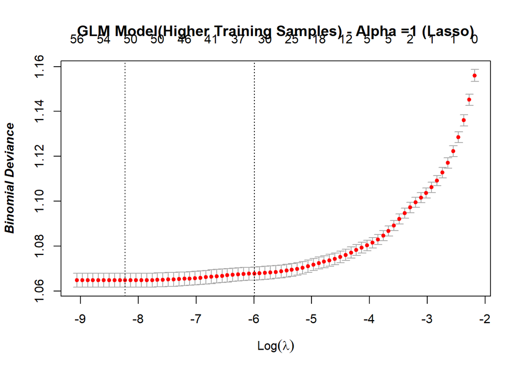

```r
#tidy(coef(glmls_cv_7, s = glmls_cv_7$lambda.1se))

plot(glmls_cv_7,main="GLM Model(Higher Training Samples) - Alpha =1 (Lasso)",
        font.main=2, font.lab=4, font.sub=4)
```

```r
# How to select lambda - Lambda min or 1 SE

# Getting the index to 1 SE

which(glmls_cv_7$lambda == glmls_cv$lambda.1se)
```

```
## integer(0)
```

```r
# Ratio corresponding to 1 SE

glmls_cv_7$glmnet.fit$dev.ratio[which(glmls_cv_7$lambda == glmls_cv_7$lambda.1se) ]
```

```
## [1] 0.07797815
```

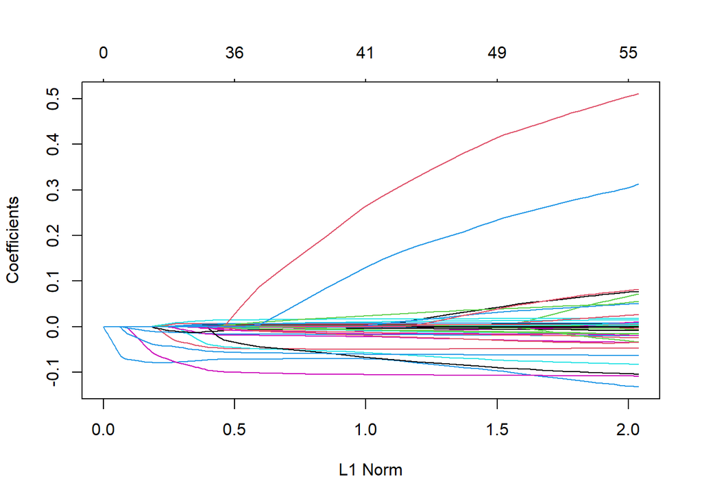

```r
plot(glmls_cv_7$glmnet.fit)
```

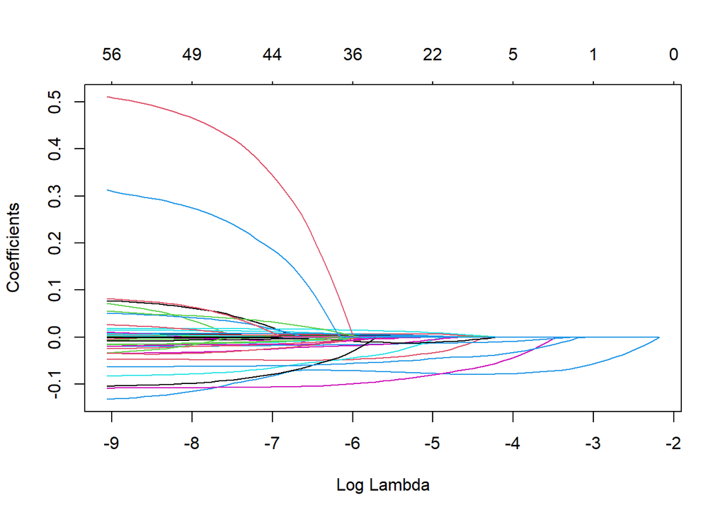

```r
plot(glmls_cv_7$glmnet.fit, xvar="lambda")
```

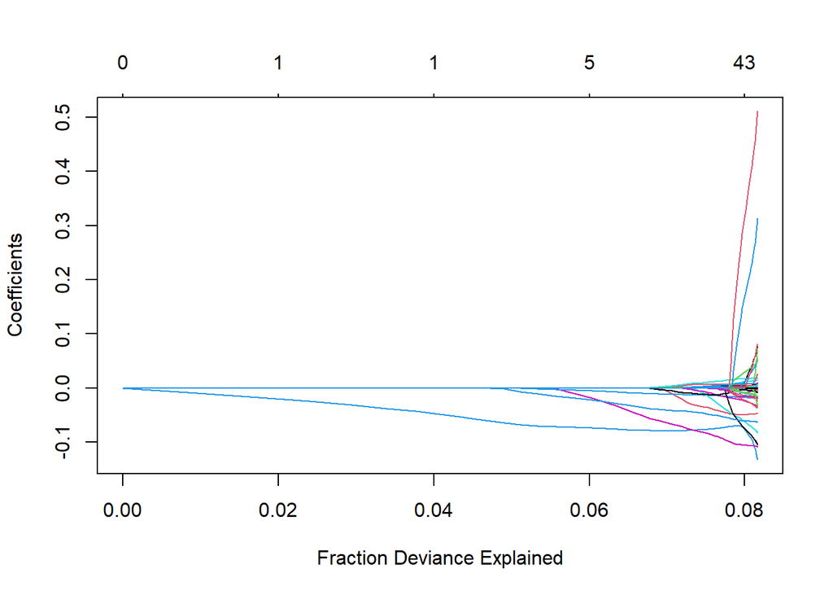

```r
plot(glmls_cv_7$glmnet.fit, xvar="dev")
```

```r
# Predictions - Train data

glmPredls_1=predict ( glmls_cv_7,data.matrix(xDTrn7), s="lambda.min") # This gives the ln(odds)

glmPredls_pc=predict(glmls_cv_7,data.matrix(xDTrn7), s="lambda.min", type="class" ) # Gives probability of 1 - Fully Paid in our case

glmPredls_pr=predict(glmls_cv_7,data.matrix(xDTrn7), s="lambda.min", type="response" )

# doubt about what is response - class and response

## ROC on train data


predsauc <- prediction(glmPredls_pr, lcdfTrn7$loan_status, label.ordering = c("Charged Off", "Fully Paid"))

aucPerf <- performance(predsauc, "auc")

aucPerf@y.values
```

```
## [[1]]
## [1] 0.6956235
```

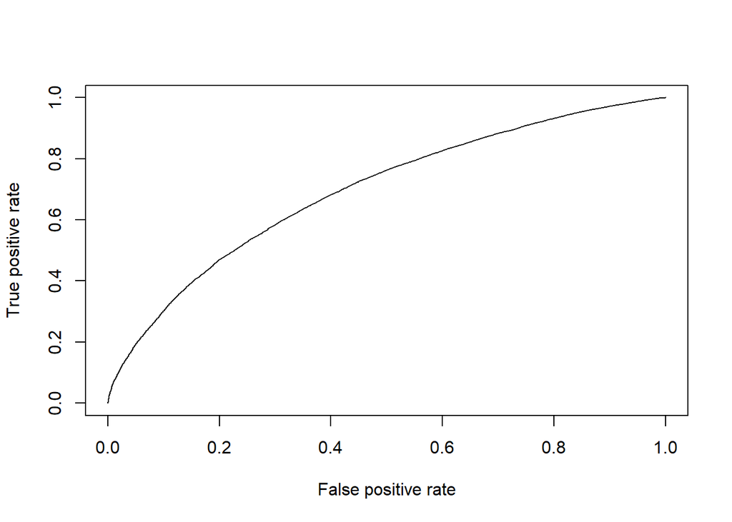

```r
aucPerf <- performance(predsauc, "tpr","fpr")

plot(aucPerf)
```

```r
## Confusion matrix on train data


confusionMatrix(factor(glmPredls_pc, levels = c(1,0)), yTrn7, positive = "1")
```

```
## Confusion Matrix and Statistics
##
##           Reference
## Prediction     0     1
##          0  1234  2268
##          1  8473 58021
##
##                Accuracy : 0.8465
##                  95% CI : (0.8439, 0.8492)
##     No Information Rate : 0.8613
##     P-Value [Acc > NIR] : 1
##
##                   Kappa : 0.1223
##
##  Mcnemar's Test P-Value : <0.0000000000000002
##
##             Sensitivity : 0.9624
##             Specificity : 0.1271
##          Pos Pred Value : 0.8726
##          Neg Pred Value : 0.3524
##              Prevalence : 0.8613
##          Detection Rate : 0.8289
##    Detection Prevalence : 0.9500
##       Balanced Accuracy : 0.5448
##
##        'Positive' Class : 1
##
```

```r
## Test data

glmPredls_pc=predict(glmls_cv_7,data.matrix(xDTst7), s="lambda.min", type="class" ) # Gives probability of 1 - Fully Paid in our case

glmPredls_pr=predict(glmls_cv_7,data.matrix(xDTst7), s="lambda.min", type="response" )



## Test data predictions

glmPredls_pc=predict(glmls_cv_7,data.matrix(xDTst7), s="lambda.min", type="class" ) # Gives probability of 1 - Fully Paid in our case

glmPredls_pr=predict(glmls_cv_7,data.matrix(xDTst7), s="lambda.min", type="response" )



## ROC Curve on the test data


predsauc <- prediction(glmPredls_pr, lcdfTst7$loan_status, label.ordering = c("Charged Off", "Fully Paid"))

aucPerf <- performance(predsauc, "auc")

aucPerf@y.values
```

```
## [[1]]
## [1] 0.678492
```

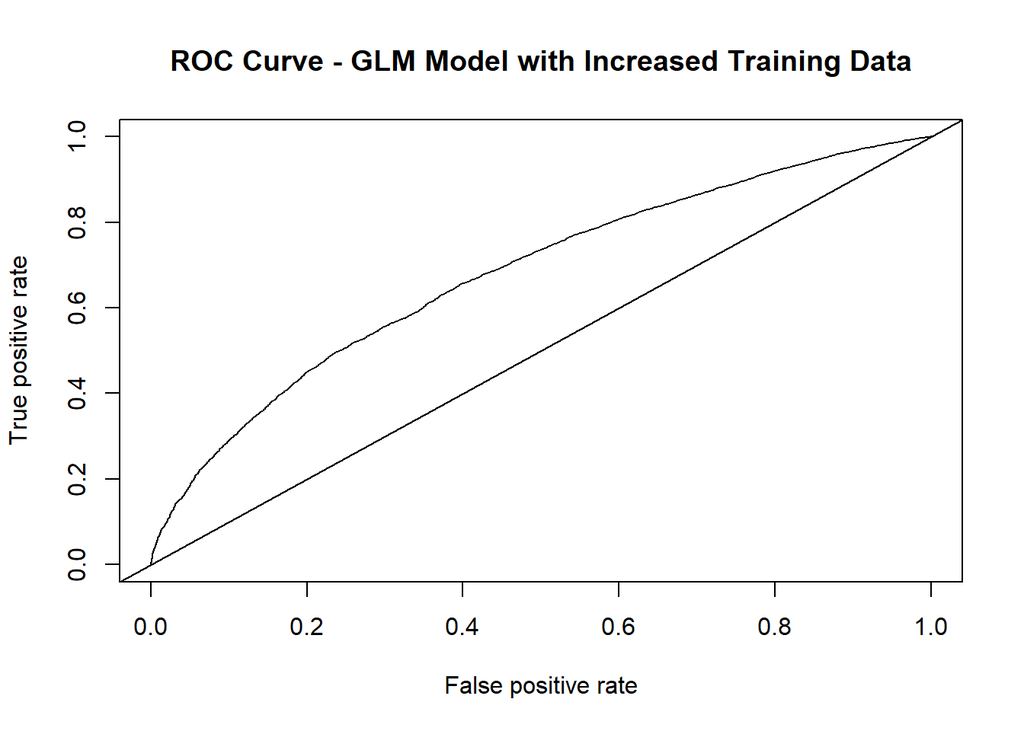

```r
aucPerf <- performance(predsauc, "tpr","fpr")

plot(aucPerf,main="ROC Curve - GLM Model with Increased Training Data")
abline(a=0, b= 1)
```

```r
# Confusion Matrix


confusionMatrix(factor(glmPredls_pc, levels = c(1,0)), yTst7, positive = "1")
```

```
## Confusion Matrix and Statistics
##
##           Reference
## Prediction     0     1
##          0   473  1011
##          1  3604 24910
##
##                Accuracy : 0.8462
##                  95% CI : (0.842, 0.8502)
##     No Information Rate : 0.8641
##     P-Value [Acc > NIR] : 1
##
##                   Kappa : 0.1052
##
##  Mcnemar's Test P-Value : <0.0000000000000002
##
##             Sensitivity : 0.9610
##             Specificity : 0.1160
##          Pos Pred Value : 0.8736
##          Neg Pred Value : 0.3187
##              Prevalence : 0.8641
##          Detection Rate : 0.8304
##    Detection Prevalence : 0.9505
##       Balanced Accuracy : 0.5385
##
##        'Positive' Class : 1
##
```

```r
#################### Using lambda = 1.se

glmls_1se <- glmnet(data.matrix(xDTrn7), yTrn7, family="binomial", lambda = glmls_cv$lambda.1se)



# Comparing coeficients
tidy(glmls_1se)
```

```
## # A tibble: 13 × 5
##    term                  step     estimate  lambda dev.ratio
##    <chr>                <dbl>        <dbl>   <dbl>     <dbl>
##  1 (Intercept)              1  3.17        0.00625    0.0630
##  2 sub_grade                1 -0.0779      0.00625    0.0630
##  3 emp_length               1  0.00582     0.00625    0.0630
##  4 home_ownership           1 -0.0722      0.00625    0.0630
##  5 annual_inc               1  0.000000272 0.00625    0.0630
##  6 verification_status      1 -0.0158      0.00625    0.0630
##  7 dti                      1 -0.0126      0.00625    0.0630
##  8 acc_open_past_24mths     1 -0.0424      0.00625    0.0630
##  9 bc_open_to_buy           1  0.00000247  0.00625    0.0630
## 10 mort_acc                 1  0.00387     0.00625    0.0630
## 11 mths_since_recent_bc     1  0.000615    0.00625    0.0630
## 12 num_actv_rev_tl          1 -0.00630     0.00625    0.0630
## 13 tot_hi_cred_lim          1  0.000000461 0.00625    0.0630
```

```r
#tidy(coef(glmls_cv, s=glmls_cv$lambda.1se))


###### Variable importance

library(vip)
tb1 <- vi_model(glmls_cv)

arrange(tb1,desc(Importance),Variable)
```

```
## # A tibble: 64 × 3
##    Variable              Importance Sign
##    <chr>                      <dbl> <chr>
##  1 sub_grade               0.0761   NEG
##  2 home_ownership          0.0597   NEG
##  3 acc_open_past_24mths    0.0416   NEG
##  4 dti                     0.0132   NEG
##  5 verification_status     0.0118   NEG
##  6 emp_length              0.00897  POS
##  7 mort_acc                0.00497  POS
##  8 num_actv_rev_tl         0.00455  NEG
##  9 mths_since_recent_inq   0.00296  POS
## 10 mo_sin_rcnt_tl          0.000918 POS
## # … with 54 more rows
```

# GLM (Lasso and Ridge) - To find the actual returns

```r
# Building the GLM model - since we are predicting the continuous variable we will use the gaussian family and alpha =1 for lasso regression

glmRet_cv_lasso <- cv.glmnet(data.matrix(xDTrn), lcdfTrn$actualReturn, family='gaussian', alpha=1)

glmRet_cv_las <- predict(glmRet_cv_lasso, data.matrix(xDTst))

sqrt(mean( (glmRet_cv_las - lcdfTst$actualReturn)^2))
```

```
## [1] 8.218781
```

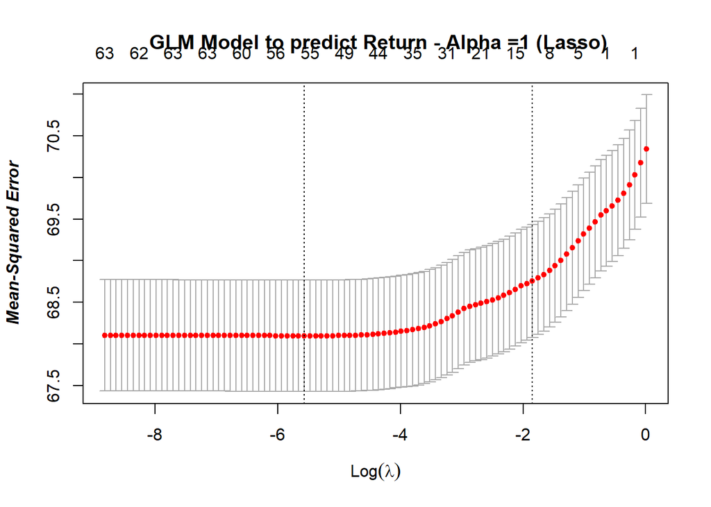

```r
# Plot

plot(glmRet_cv_lasso,main=" GLM Model to predict Return - Alpha =1 (Lasso)",
        font.main=2, font.lab=4, font.sub=4)
```

```r
# When lambda is minimum

glmRet_cv_lasso$lambda.min
```

```
## [1] 0.003819432
```

```r
#coef(glmRet_cv_lasso, s="lambda.min") %>% tidy()

glmRet_cv_lasso$lambda.1se
```

```
## [1] 0.1578194
```

```r
#coef(glmRet_cv_lasso, s="lambda.1se") %>% tidy()



# Building the GLM model - since we are predicting the continuous variable we will use the gaussian family and alpha =0 for ridge regression

glmRet_cv_ridge <- cv.glmnet(data.matrix(xDTrn), lcdfTrn$actualReturn, family='gaussian', alpha=0)

glmRet_cv_rid <- predict(glmRet_cv_ridge, data.matrix(xDTst))

sqrt(mean( (glmRet_cv_rid - lcdfTst$actualReturn)^2))
```

```
## [1] 8.222314
```

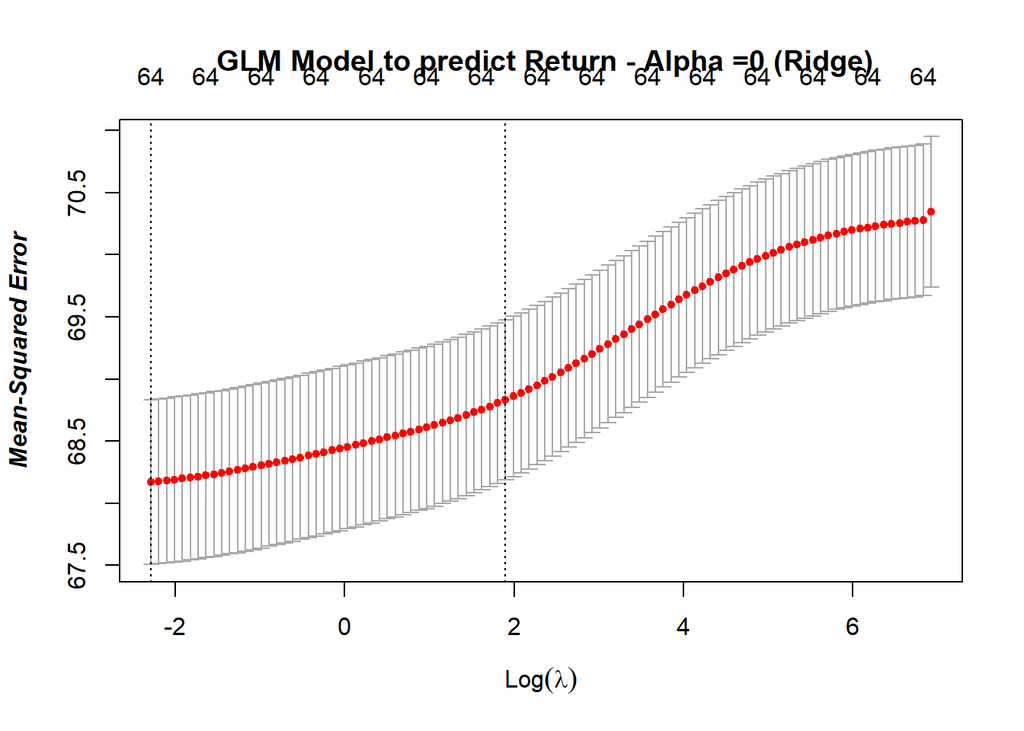

```r
# Plot

plot(glmRet_cv_ridge,main=" GLM Model to predict Return - Alpha =0 (Ridge)",
        font.main=2, font.lab=4, font.sub=4)
```

```r
# When lambda is minimum

glmRet_cv_ridge$lambda.min
```

```
## [1] 0.1014475
```

```r
#coef(glmRet_cv_ridge, s="lambda.min") %>% tidy()

glmRet_cv_ridge$lambda.1se
```

```
## [1] 6.674565
```

```r
#coef(glmRet_cv_ridge, s="lambda.1se") %>% tidy()


# Building the GLM model - since we are predicting the continuous variable we will use the gaussian family and alpha =0.2 for elastic net

glmRet_cv_a2 <- cv.glmnet(data.matrix(xDTrn), lcdfTrn$actualReturn, family='gaussian', alpha=0.2)

glmRet_cv_a2predict <- predict(glmRet_cv_a2, data.matrix(xDTst))

sqrt(mean( (glmRet_cv_a2predict - lcdfTst$actualReturn)^2))
```

```
## [1] 8.218262
```

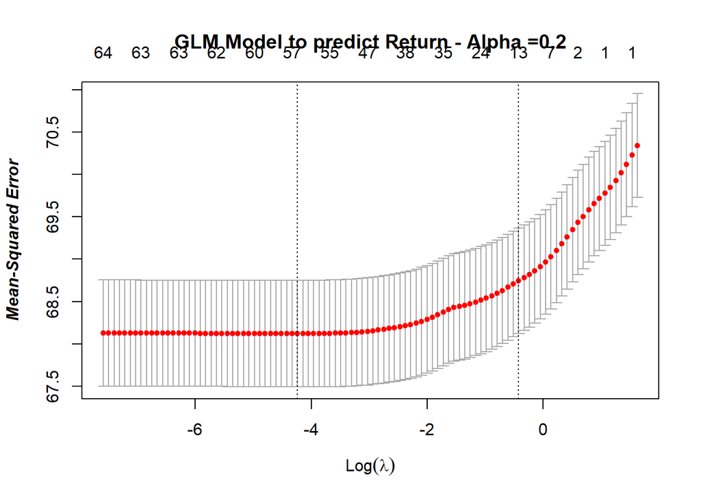

```r
# Plot

plot(glmRet_cv_a2,main=" GLM Model to predict Return - Alpha =0.2 ",
        font.main=2, font.lab=4, font.sub=4)
```

```r
# When lambda is minimum

glmRet_cv_a2$lambda.min
```

```
## [1] 0.0144463
```

```r
#coef(glmRet_cv_a2, s="lambda.min") %>% tidy()

glmRet_cv_a2$lambda.1se
```

```
## [1] 0.6551221
```

```r
#coef(glmRet_cv_a2, s="lambda.1se") %>% tidy()


# Building the GLM model - since we are predicting the continuous variable we will use the gaussian family and alpha =0.5 for elastic net

glmRet_cv_a5 <- cv.glmnet(data.matrix(xDTrn), lcdfTrn$actualReturn, family='gaussian', alpha=0.5)
glmRet_cv_a5predict <- predict(glmRet_cv_a5, data.matrix(xDTrn))
sqrt(mean( (glmRet_cv_a5predict - lcdfTrn$actualReturn)^2))
```

```
## [1] 8.296104
```

```r
glmRet_cv_a5predict <- predict(glmRet_cv_a5, data.matrix(xDTst))
sqrt(mean( (glmRet_cv_a5predict - lcdfTst$actualReturn)^2))
```

```
## [1] 8.223928
```

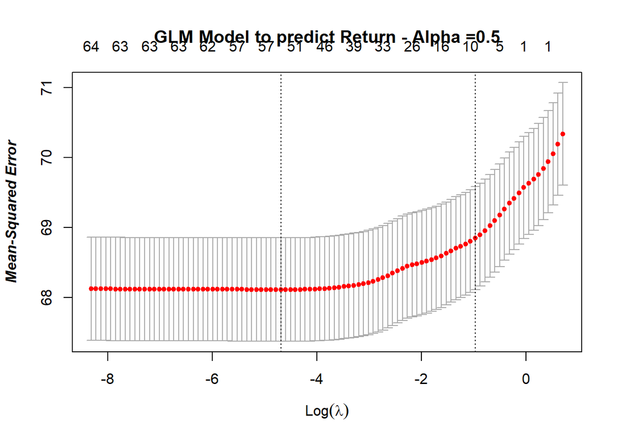

```r
# Plot

plot(glmRet_cv_a5,main=" GLM Model to predict Return - Alpha =0.5 ",
        font.main=2, font.lab=4, font.sub=4)
```

```r
# When lambda is minimum

glmRet_cv_a5$lambda.min
```

```
## [1] 0.009201038
```

```r
#coef(glmRet_cv_a5, s="lambda.min") %>% tidy()

glmRet_cv_a5$lambda.1se
```

```
## [1] 0.380188
```

```r
#coef(glmRet_cv_a5, s="lambda.1se") %>% tidy()
```

### Predicting Returns - Using Random Forest

```r
rfModel_Ret <- ranger(actualReturn ~., data=subset(lcdfTrn, select=-c(annRet, actualTerm, loan_status)), num.trees =200, importance='permutation')

rfPredRet_trn<- predict(rfModel_Ret, lcdfTrn)

#Train
sqrt(mean( (rfPredRet_trn$predictions - lcdfTrn$actualReturn)^2))
```

```
## [1] 1.882791
```

```r
#Test
sqrt(mean( ( (predict(rfModel_Ret, lcdfTst))$predictions - lcdfTst$actualReturn)^2))
```

```
## [1] 4.263838
```

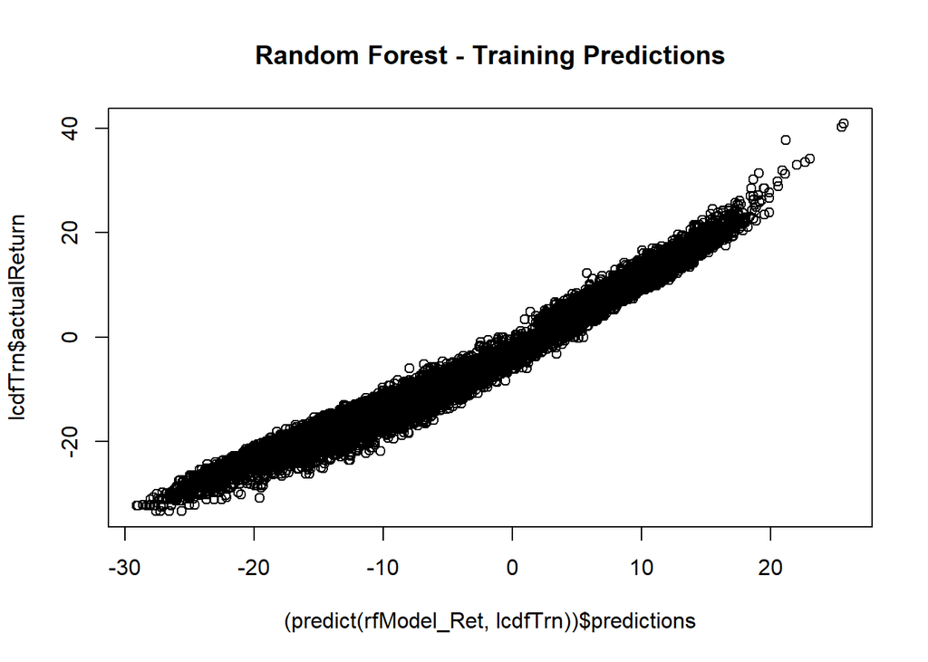

```r
plot ( (predict(rfModel_Ret, lcdfTrn))$predictions, lcdfTrn$actualReturn, main='Random Forest - Training Predictions')
```

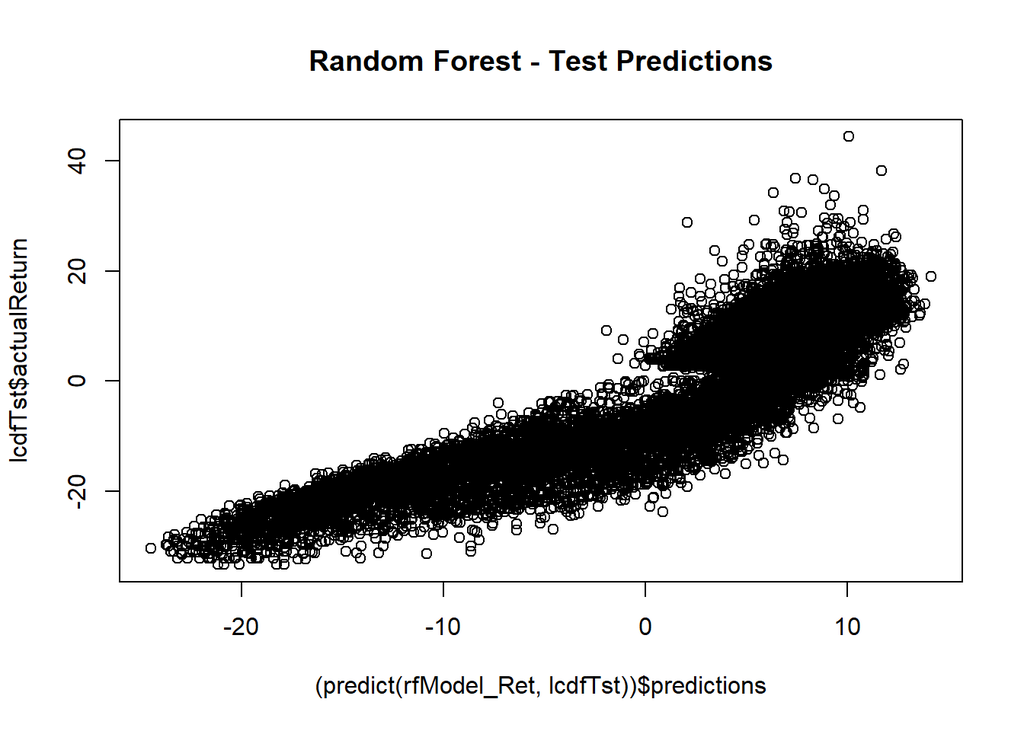

```r
plot ( (predict(rfModel_Ret, lcdfTst))$predictions, lcdfTst$actualReturn, main='Random Forest - Test Predictions')
```

```r
#Performance by deciles - Training data

predRet_Trn <- lcdfTrn %>% select(grade, loan_status, actualReturn, actualTerm, int_rate) %>% mutate(predRet=(predict(rfModel_Ret, lcdfTrn))$predictions)




predRet_Trn <- predRet_Trn %>% mutate(tile=ntile(-predRet, 10))

predRet_Trn %>% group_by(tile) %>% summarise(count=n(), avgpredRet=mean(predRet), numDefaults=sum(loan_status=="Charged Off"), avgActRet=mean(actualReturn), minRet=min(actualReturn), maxRet=max(actualReturn), avgTer=mean(actualTerm), totA=sum(grade=="A"), totB=sum(grade=="B" ), totC=sum(grade=="C"), totD=sum(grade=="D"), totE=sum(grade=="E"), totF=sum(grade=="F") )
```

```
## # A tibble: 10 × 14
##     tile count avgpred…¹ numDe…² avgAc…³  minRet maxRet avgTer  totA  totB  totC
##    <int> <int>     <dbl>   <int>   <dbl>   <dbl>  <dbl>  <dbl> <int> <int> <int>
##  1     1  5000     12.5        5   14.7    9.81  40.8     1.29     0    57  1389
##  2     2  5000      9.98      15   11.1    7.38  16.6     1.74     3   811  2370
##  3     3  5000      8.74      31    9.48   6.76  14.2     1.99     3  1660  2499
##  4     4  5000      7.80      40    8.22   5.20  12.9     2.25    28  2250  2535
##  5     5  5000      6.97      66    7.26   3.22  11.8     2.38   195  3071  1666
##  6     6  5000      6.16     105    6.45   2.13  12.2     2.28   908  3611   426
##  7     7  5000      5.28     120    5.49  -0.208  9.04    2.24  2272  2589    90
##  8     8  4999      4.40     156    4.45  -0.662  8.32    2.50  3892   979    80
##  9     9  4999      2.68    1402    1.82  -9.57   6.65    2.75  3596   568   483
## 10    10  4999    -12.6     4999  -16.5  -33.3   -0.918   3      412  1346  1701
## # … with 3 more variables: totD <int>, totE <int>, totF <int>, and abbreviated
## #   variable names ¹avgpredRet, ²numDefaults, ³avgActRet
```

```r
#Performance by deciles - Test data

predRet_Tst <- lcdfTst %>% select(grade, loan_status, actualReturn, actualTerm, int_rate) %>% mutate(predRet=(predict(rfModel_Ret, lcdfTst))$predictions)



predRet_Tst <- predRet_Tst %>% mutate(tile=ntile(-predRet, 10))

predRet_Tst %>% group_by(tile) %>% summarise(count=n(), avgpredRet=mean(predRet), numDefaults=sum(loan_status=="Charged Off"), avgActRet=mean(actualReturn), minRet=min(actualReturn), maxRet=max(actualReturn), avgTer=mean(actualTerm), totA=sum(grade=="A"), totB=sum(grade=="B" ), totC=sum(grade=="C"), totD=sum(grade=="D"), totE=sum(grade=="E"), totF=sum(grade=="F") )
```

```
## # A tibble: 10 × 14
##     tile count avgpredRet numDe…¹ avgAc…² minRet maxRet avgTer  totA  totB  totC
##    <int> <int>      <dbl>   <int>   <dbl>  <dbl>  <dbl>  <dbl> <int> <int> <int>
##  1     1  5000      10.2      164   12.4   -6.88   44.4   2.09     0     6   836
##  2     2  5000       8.66     168   10.3   -8.49   36.6   2.10     0   309  3236
##  3     3  5000       7.85     156    9.22  -6.71   30.6   2.12     0  1364  3088
##  4     4  5000       7.21     176    8.43  -9.37   36.9   2.15     0  2744  1990
##  5     5  5000       6.59     213    7.72 -14.3    34.2   2.17     0  3444  1362
##  6     6  5000       5.82     229    6.65 -15.0    24.9   2.19   299  3963   621
##  7     7  5000       5.06     248    5.54 -15.0    29.2   2.23  2235  2421   269
##  8     8  4999       4.36     251    4.65 -14.1    19.3   2.22  3926   864   157
##  9     9  4999       3.54     525    3.31 -17.2    23.7   2.34  4202   520   166
## 10    10  4999      -7.54    4715  -15.3  -33.3    28.9   2.94   615  1329  1680
## # … with 3 more variables: totD <int>, totE <int>, totF <int>, and abbreviated
## #   variable names ¹numDefaults, ²avgActRet
```

### Random Forest - To predict the returns

```r
# Building the regression model to predict the actual returns


rfModel_Ret500 <- ranger(actualReturn ~., data=subset(lcdfTrn, select=-c(actualTerm, loan_status)), num.trees =500, importance='permutation')
# Predicting on the train set

rfPredRet_trn<- predict(rfModel_Ret500, lcdfTrn)

# Checking the loss - MSE

sqrt(mean( (rfPredRet_trn$predictions - lcdfTrn$actualReturn)^2))
```

```
## [1] 0.8352786
```

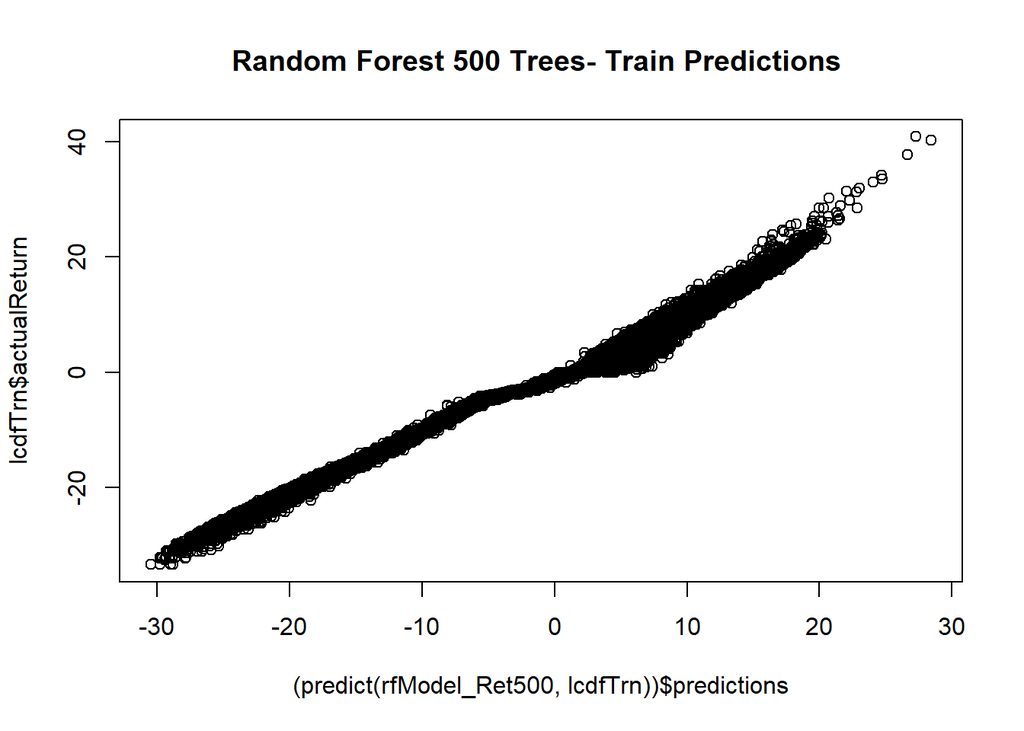

```r
plot ((predict(rfModel_Ret500, lcdfTrn))$predictions, lcdfTrn$actualReturn, main='Random Forest 500 Trees- Train Predictions ')
```

```r
# Checking the loss - MSE on test data

sqrt(mean( ( (predict(rfModel_Ret500, lcdfTst))$predictions - lcdfTst$actualReturn)^2))
```

```
## [1] 2.00522
```

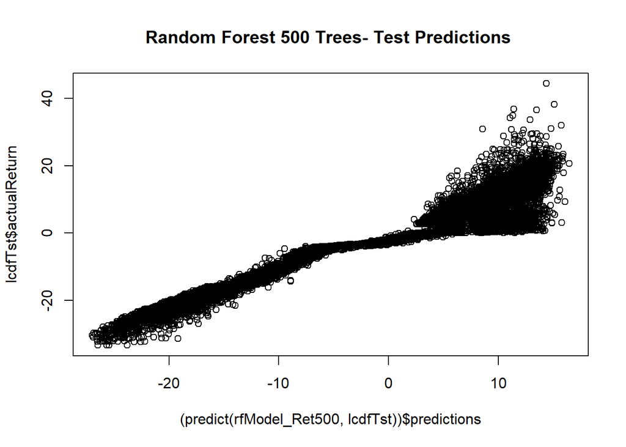

```r
plot ( (predict(rfModel_Ret500, lcdfTst))$predictions, lcdfTst$actualReturn, main='Random Forest 500 Trees- Test Predictions ')
```

```r
# Evaluation of the random forest model - by deciles

#Performance by deciles- Training data

predRet_Trn <- lcdfTrn %>% select(grade, loan_status, actualReturn, actualTerm, int_rate) %>% mutate(predRet=(predict(rfModel_Ret500, lcdfTrn))$predictions)

predRet_Trn <- predRet_Trn %>% mutate(tile=ntile(-predRet, 10))


predRet_Trn %>% group_by(tile) %>% summarise(count=n(), avgpredRet=mean(predRet), numDefaults=sum(loan_status=="Charged Off"), avgActRet=mean(actualReturn), minRet=min(actualReturn), maxRet=max(actualReturn), avgTer=mean(actualTerm), totA=sum(grade=="A"), totB=sum(grade=="B" ), totC=sum(grade=="C"), totD=sum(grade=="D"), totE=sum(grade=="E"), totF=sum(grade=="F") )
```

```
## # A tibble: 10 × 14
##     tile count avgpred…¹ numDe…² avgAc…³  minRet maxRet avgTer  totA  totB  totC
##    <int> <int>     <dbl>   <int>   <dbl>   <dbl>  <dbl>  <dbl> <int> <int> <int>
##  1     1  5000     13.6        3   14.8   10.0    40.8    1.20     0    61  1466
##  2     2  5000     10.7       25   11.1    6.81   15.3    1.71     2   872  2240
##  3     3  5000      9.34      54    9.48   4.26   12.8    1.95     4  1734  2215
##  4     4  5000      8.23      71    8.20   2.45   11.8    2.24    42  2083  2792
##  5     5  5000      7.34     105    7.21   0.975   9.95   2.42   255  2648  2045
##  6     6  5000      6.51     133    6.37   0       8.47   2.34   865  3861   213
##  7     7  5000      5.58     156    5.47   0.292   7.32   2.26  2015  2875    88
##  8     8  4999      4.63     121    4.47   0       6.65   2.52  3911  1026    51
##  9     9  4999      2.19    1272    1.88  -6.44    4.78   2.77  3795   456   431
## 10    10  4999    -15.8     4999  -16.6  -33.3    -5.11   3      420  1326  1698
## # … with 3 more variables: totD <int>, totE <int>, totF <int>, and abbreviated
## #   variable names ¹avgpredRet, ²numDefaults, ³avgActRet
```

```r
#Performance by deciles- Test data

predRet_Tst <- lcdfTst %>% select(grade, loan_status, actualReturn, actualTerm, int_rate) %>% mutate(predRet=(predict(rfModel_Ret500, lcdfTst))$predictions)


predRet_Tst <- predRet_Tst %>% mutate(tile=ntile(-predRet, 10))


predRet_Tst %>% group_by(tile) %>% summarise(count=n(), avgpredRet=mean(predRet), numDefaults=sum(loan_status=="Charged Off"), avgActRet=mean(actualReturn), minRet=min(actualReturn), maxRet=max(actualReturn), avgTer=mean(actualTerm), totA=sum(grade=="A"), totB=sum(grade=="B" ), totC=sum(grade=="C"), totD=sum(grade=="D"), totE=sum(grade=="E"), totF=sum(grade=="F") )
```

```
## # A tibble: 10 × 14
##     tile count avgpred…¹ numDe…² avgAc…³  minRet maxRet avgTer  totA  totB  totC
##    <int> <int>     <dbl>   <int>   <dbl>   <dbl>  <dbl>  <dbl> <int> <int> <int>
##  1     1  5000     12.3      295   13.6    0      44.4    1.66     0     0   585
##  2     2  5000     10.3      170   10.9    0      28.9    1.86     0   184  2827
##  3     3  5000      9.15     145    9.60   0.206  24.9    1.90     0  1280  3525
##  4     4  5000      8.27      65    8.36   0      30.9    2.25     0  2043  2951
##  5     5  5000      7.50      45    7.42   0.358  18.5    2.39     0  3649  1350
##  6     6  5000      6.64      42    6.58   0      18.4    2.32   295  4668    32
##  7     7  5000      5.64      43    5.70  -0.764  16.9    2.14  2081  2898    15
##  8     8  4999      4.78      35    4.68  -1.19   11.1    2.34  4408   560    20
##  9     9  4999      2.86    1006    2.35  -7.55    8.66   2.69  4067   345   353
## 10    10  4999    -14.7     4999  -16.3  -33.3    -3.94   3      426  1337  1747
## # … with 3 more variables: totD <int>, totE <int>, totF <int>, and abbreviated
## #   variable names ¹avgpredRet, ²numDefaults, ³avgActRet
```

### XGBoost - To predict the returns

```r
library(xgboost)
library(caret)


#lcdf <- lcdfx
str(lcdf)
```

```
## tibble [99,994 × 69] (S3: tbl_df/tbl/data.frame)
##  $ loan_amnt                 : num [1:99994] 28000 6150 7200 4750 5000 9600 1600 12000 25000 4800 ...
##  $ funded_amnt               : num [1:99994] 28000 6150 7200 4750 5000 9600 1600 12000 25000 4800 ...
##  $ int_rate                  : num [1:99994] 5.32 13.33 14.99 15.31 12.69 ...
##  $ installment               : num [1:99994] 843 208 250 165 168 ...
##  $ grade                     : Factor w/ 7 levels "A","B","C","D",..: 1 3 3 3 3 3 3 2 3 3 ...
##  $ sub_grade                 : Factor w/ 35 levels "A1","A2","A3",..: 1 13 15 14 12 13 13 7 12 12 ...
##  $ emp_length                : Factor w/ 12 levels "n/a","< 1 year",..: 11 8 5 1 3 12 12 2 12 2 ...
##  $ home_ownership            : Factor w/ 3 levels "MORTGAGE","OWN",..: 1 3 3 1 1 1 3 1 1 1 ...
##  $ annual_inc                : num [1:99994] 140000 40000 20000 30000 27000 48500 50000 65000 98000 100000 ...
##  $ verification_status       : Factor w/ 3 levels "Not Verified",..: 2 2 2 3 3 3 3 2 3 1 ...
##  $ loan_status               : Factor w/ 2 levels "Fully Paid","Charged Off": 1 1 1 1 1 1 1 1 1 1 ...
##  $ purpose                   : Factor w/ 11 levels "car","credit_card",..: 2 2 3 4 3 3 3 3 3 9 ...
##  $ dti                       : num [1:99994] 12.8 22.2 23.4 3.4 12.3 ...
##  $ delinq_2yrs               : num [1:99994] 0 0 0 3 0 0 0 1 6 0 ...
```

[output cut: 55 more lines]

```r
#Delete : annRet, actualTerm, total_pymnt,loan_status ( unnecessary x ) and actualReturn(y)
lcdf_act <- subset(lcdf, select=-c(actualTerm,loan_status,actualReturn))

#using one-hot encoding
fdum<-dummyVars(~.,data=lcdf_act)
dxlcdf<-predict(fdum, lcdf_act) #Matrix for x (lcdf_act)
actlcdf <- lcdf$actualReturn #Matrix for y


#Training, test subsets for xgboost (See trnIndex at the beginning)
dxlcdfTrn <- dxlcdf[trnIndex,] #Trn-x
dxlcdfTst <- dxlcdf[-trnIndex,] #Tst-x
actlcdfTrn <- actlcdf[trnIndex] #Trn-y
actlcdfTst <- actlcdf[-trnIndex] #Tst-y
eva_lcdfTrn <- lcdf[trnIndex,] #Value for evaluation
eva_lcdfTst <- lcdf[-trnIndex,] #Value for evaluation


#make data matrix
dxTrn<-xgb.DMatrix(dxlcdfTrn, label=actlcdfTrn)
dxTst<-xgb.DMatrix(dxlcdfTst, label=actlcdfTst)

#which hyper-parameters work best experiment with a grid of parameter values

#xgbParamGrid
xgbParamGrid <- expand.grid(max_depth= c(2,5),
                            eta = c(0.1, 0.01,0.001))

#Best Parameters
#for(i in 1:nrow(xgbParamGrid)) {
#  set.seed(1789)
#  xgb_tune <- xgb.cv(data = dxTrn,objective= "reg:squarederror",
#                     nrounds=500,
#                     nfold = 5,
#                     eta=xgbParamGrid$eta[i],
#                     max_depth=xgbParamGrid$max_depth[i],
#                     early_stopping_rounds= 10)
#  xgbParamGrid$bestTree[i] <- xgb_tune$evaluation_log[xgb_tune$best_iteration]$iter
# xgbParamGrid$bestPerf[i] <- xgb_tune$evaluation_log[xgb_tune$best_iteration]$test_rmse_mean
#}

#view ParamGrid
#xgbParamGrid

#Select min param
best_index_ParamGrid <- which.min(xgbParamGrid$bestPerf)
best_index_ParamGrid
```

```
## integer(0)
```

```r
# we get max_depth =2 , bestTree = 67, ,eta= 0.1
best_rounds = xgbParamGrid$bestTree[best_index_ParamGrid]     # bestTree =67
best_max.depth = xgbParamGrid$max_depth[best_index_ParamGrid] #max_depth = 2
best_eta = xgbParamGrid$eta[best_index_ParamGrid]             #eta= 0.1

#xgboost Training
set.seed(123)
xgb_Mr <- xgboost( data = dxTrn,
                   nrounds=67,
                  max.depth=2 ,
                  eta=0.1,
                  objective="reg:squarederror")
#variable importance
xgb.importance(model=xgb_Mr)
```

```
##     Feature          Gain       Cover   Frequency
## 1:   annRet 0.90380363247 0.597286156 0.641791045
## 2: int_rate 0.09609735442 0.395251157 0.353233831
## 3:  grade.A 0.00009901311 0.007462687 0.004975124
```

```r
#evaluation Training
predXgbRet_Trn <- eva_lcdfTrn %>% select(grade, loan_status, actualReturn, actualTerm, int_rate) %>%
  mutate(predXgbRet=predict(xgb_Mr,dxTrn))

head(predXgbRet_Trn)
```

```
## # A tibble: 6 × 6
##   grade loan_status actualReturn actualTerm int_rate predXgbRet
##   <fct> <fct>              <dbl>      <dbl>    <dbl>      <dbl>
## 1 E     Charged Off       -18.8       3        19.0      -18.2
## 2 C     Charged Off       -10.2       3        13.4      -10.1
## 3 B     Fully Paid          4.90      3.00      9.17       5.78
## 4 C     Fully Paid         11.1       0.835    13.3        9.98
## 5 B     Charged Off       -13.5       3        12.5      -13.5
## 6 B     Fully Paid          9.11      1.59     11.5        7.86
```

```r
nrow(predXgbRet_Trn)
```

```
## [1] 69996
```

```r
#xgboost Testing
set.seed(1789)
xgb_tst <- xgboost( data = dxTst,
                    nrounds=67,
                    max.depth=2 ,
                    eta=0.1,
                    objective="reg:squarederror")
#variable importance
xgb.importance(model=xgb_tst)
```

```
##         Feature          Gain       Cover   Frequency
## 1:       annRet 0.89880901454 0.593732866 0.636815920
## 2:     int_rate 0.10114426432 0.405157856 0.358208955
## 3: sub_grade.A1 0.00004672114 0.001109278 0.004975124
```

```r
#evaluation Testing
predXgbRet_Tst <- eva_lcdfTst %>% select(grade, loan_status, actualReturn, actualTerm, int_rate) %>%
  mutate(predXgbRet=predict(xgb_tst,dxTst))


nrow(dxTst)
```

```
## [1] 29998
```

```r
nrow(xgb_tst)
```

[output not shown]

```r
view(predXgbRet_Tst)
nrow(predXgbRet_Tst)
```

```
## [1] 29998
```

#### Combining Models -

```r
#d=1
#pRetSc <- predRet_Tst %>% mutate(poScore=predRet_Tst$predRet)

#pRet_d <- pRetSc %>% filter(tile<=d)

#pRet_d<- pRet_d %>% mutate(tile2=ntile(-poScore, 20))
#pRet_d %>% group_by(tile2) %>% summarise(count=n(), avgPredRet=mean(predRet), numDefaults=sum(loan_status=="Charged Off"), avgActRet=mean(actualReturn), minRet=min(actualReturn), maxRet=max(actualReturn), avgTer=mean(actualTerm), totA=sum(grade=="A"), totB=sum(grade=="B" ),
#totC=sum(grade=="C"), totD=sum(grade=="D"), totE=sum(grade=="E"), totF=sum(grade=="F") )


#pRet_d<- predRet_Tst_new%>% mutate(tile2=ntile(-expRet, 20))
#pRet_d %>% group_by(tile2) %>% summarise(count=n(), avgPredRet=mean(predRet), numDefaults=sum(loan_status=="Charged Off"), avgActRet=mean(actualReturn), minRet=min(actualReturn), maxRet=max(actualReturn), avgTer=mean(actualTerm), totA=sum(grade=="A"), totB=sum(grade=="B" ),
#totC=sum(grade=="C"), totD=sum(grade=="D"), totE=sum(grade=="E"), totF=sum(grade=="F") )
```